# Model Notebook Documentation

# Methodology

This project follows the [CRISP-DM (Cross-Industry Standard Process for Data Mining) methodology,](https://en.wikipedia.org/wiki/Cross-industry_standard_process_for_data_mining) which provides a structured framework for developing machine learning solutions. The methodology is divided into six main phases:

1. **Business Understanding:** Define the objectives of the regression challenge, understand the expected outputs, and identify the success criteria for the predictive model.
2. **Data Understanding:** Explore the training dataset to analyze feature distributions, detect potential anomalies, and understand relationships between variables and the target.
3. **Data Preparation:** Perform preprocessing and transformation tasks when necessary, including data cleaning, scaling, and feature engineering to improve model quality.
4. **Modeling:** Train and compare multiple regression models using the prepared dataset in order to identify the best predictive approach.
5. **Evaluation:** Assess model performance using appropriate regression metrics and validation techniques while monitoring possible overfitting.
6. **Deployment:** Generate predictions for the blind test dataset using the final selected model and prepare the results for submission.

## a) Libraries

All libraries used in this notebook are declared here so the rest of the document can remain focused on analysis and modeling rather than setup details.

The following chunk bootstraps the software environment for the notebook. It checks which packages are already available, installs any missing dependency, and then loads the libraries needed for data manipulation, visualization, modeling, and diagnostics.

```r
# Define the package set once so the notebook can reproduce itself on a clean machine.
required_packages <- c(
  "tidyverse", "tidymodels", "conflicted",
  "DiagrammeR", "printtree", "glmnet", "ranger", "car",
  "skimr", "naniar", "visdat"
)

missing_required_packages <- required_packages[
  !vapply(required_packages, requireNamespace, quietly = TRUE, FUN.VALUE = logical(1))
]

if (length(missing_required_packages) > 0) {
  install.packages(missing_required_packages, repos = "https://cloud.r-project.org")
}

# Load the libraries used throughout the workflow.
library(tidyverse)
library(tidymodels)
library(conflicted)
library(DiagrammeR)
library(printtree)
library(glmnet)
library(ranger)
library(car)
library(skimr)
library(naniar)
library(visdat)
library(broom)
library(recipes)
library(rsample)
library(parsnip)
library(workflows)
library(tune)
library(dials)
library(yardstick)



# Resolve common naming conflicts up front so later chunks remain readable.
conflict_prefer("filter", "dplyr")
conflict_prefer("lag", "dplyr")
conflict_prefer("select", "dplyr")
conflict_prefer("step", "recipes")

# Keep plots and numeric printing consistent across the notebook.
theme_set(theme_minimal())
options(scipen = 999)
```

## b) Repository Structure

Reusable repository in GitHub: https://github.com/juanjo-edm/multivariate-regression-in-R

The repository has been simplified so that the notebook is the main artifact. The only persistent output expected from the analytical flow is the final prediction file stored in `output/`.

```r
printtree::print_rtree()
```

```
multivariate regression in R/
|-- data/
|   `-- raw/
|       |-- blind_test_data.csv
|       `-- training_data.csv
|-- documents/
|   |-- References/
|   |   |-- Hadley Wickham - Mastering Shiny (2021).pdf
|   |   |-- inferencia causal.pdf
|   |   |-- Political data science .pdf
|   |   `-- Tidy Modeling with R (Early Release)... (z-lib.org).pdf
|   `-- ML Modeling Challenge _ DS Hiring _ Wizeline (1).pdf
|-- figure/
|   |-- data-quality-profile-1.png
|   |-- data-quality-profile-2.png
|   |-- feature-boxplots-1.png
|   |-- feature-distributions-1.png
|   |-- modeling-comparison-plot-1.png
|   |-- ols-predicted-actual-1.png
|   |-- ols-qqplot-1.png
|   |-- ols-residuals-fitted-1.png
|   |-- ols-scale-location-1.png
|   |-- predictor-heatmap-1.png
|   |-- target-boxplot-1.png
|   |-- target-distribution-1.png
|   |-- target-violin_plot-1.png
|   |-- top-correlations-plot-1.png
|   |-- top-feature-scatter-1.png
|   |-- winning-model-error-profile-1.png
|   |-- winning-model-predicted-actual-1.png
|   `-- winning-random-forest-importance-1.png
|-- images/
|   `-- clipboard-3737925313.png
|-- output/
|   |-- Presentation/
|   |   |-- assets/
|   |   |   |-- modeling-comparison-plot-1.png
|   |   |   |-- predictor-heatmap-1.png
|   |   |   |-- target-distribution-1.png
|   |   |   |-- top-correlations-plot-1.png
```

[output cut: 89 more lines]

```
|   |   |               |   `-- search.js
|   |   |               `-- zoom/
|   |   |                   |-- plugin.js
|   |   |                   |-- zoom.esm.js
|   |   |                   `-- zoom.js
|   |   |-- Methodology Presentation.html
|   |   |-- Methodology Presentation.qmd
|   |   `-- presentation.css
|   `-- blind_test_predictions.csv
|-- Model Notebook Documentation.nb.html
|-- Model Notebook Documentation.Rmd
|-- multivariate regression in R.Rproj
|-- README.md
|-- README.Rmd
`-- renv.lock
```

The next chunk turns that repository logic into a compact visual map. This helps the reader understand where the raw data enter the process, where the notebook sits, and where the final prediction file is exported.

```r
# Draw a compact diagram of the project inputs, notebook, and final output.
DiagrammeR::grViz("
digraph repo_map {
  graph [layout = dot, rankdir = LR]

  node [shape = box, style = filled, color = '#BBD7EA', fontname = Helvetica]

  raw [label = 'data/raw\\ntraining_data.csv\\nblind_test_data.csv']
  notebook [label = 'Model Notebook\\nDocumentation.Rmd']
  documents [label = 'documents\\nchallenge brief']
  output [label = 'output\\nblind_test_predictions.csv']

  raw -> notebook [label = 'read + parse + model']
  documents -> notebook [label = 'business context']
  notebook -> output [label = 'export predictions']
}
")
```

[interactive chart not shown]

## c) Notebook Structure

The notebook is organized as a single sequential document. The reader can move from the challenge description to the final prediction file without relying on external helper scripts or user-defined utility modules.

This subsection uses `printtree` on purpose. Because `printtree` renders a tree from a real filesystem path, the notebook first creates a small temporary directory structure that mirrors the logical sections of the document and then asks `printtree` to print that structure. The temporary folders are only a rendering device for documentation; they are not part of the repository and they are not part of the analytical pipeline.

The following chunk builds that temporary hierarchy and then asks `printtree` to render it. The result is a compact map of the notebook sections rather than a persistent project folder.

```r
# Create a temporary directory tree that mirrors the logical organization of the notebook.
notebook_tree_root <- file.path(tempdir(), "notebook_structure")
unlink(notebook_tree_root, recursive = TRUE, force = TRUE)

dir.create(file.path(notebook_tree_root, "Methodology", "Libraries"), recursive = TRUE, showWarnings = FALSE)
dir.create(file.path(notebook_tree_root, "Methodology", "Repository Structure"), recursive = TRUE, showWarnings = FALSE)
dir.create(file.path(notebook_tree_root, "Methodology", "Notebook Structure"), recursive = TRUE, showWarnings = FALSE)
dir.create(file.path(notebook_tree_root, "Business Understanding", "Objective"), recursive = TRUE, showWarnings = FALSE)
dir.create(file.path(notebook_tree_root, "Data Understanding"), recursive = TRUE, showWarnings = FALSE)
dir.create(file.path(notebook_tree_root, "Data Preparation"), recursive = TRUE, showWarnings = FALSE)
dir.create(file.path(notebook_tree_root, "Modeling"), recursive = TRUE, showWarnings = FALSE)
dir.create(file.path(notebook_tree_root, "Evaluation"), recursive = TRUE, showWarnings = FALSE)
dir.create(file.path(notebook_tree_root, "Deployment"), recursive = TRUE, showWarnings = FALSE)

# Print the temporary tree so the structure appears as a readable hierarchy in the notebook.
cat(
  paste(
    capture.output(printtree::print_rtree(notebook_tree_root)),
    collapse = "\n"
  )
)
```

```
notebook_structure/
|-- Business Understanding/
|   `-- Objective/
|-- Data Preparation/
|-- Data Understanding/
|-- Deployment/
|-- Evaluation/
|-- Methodology/
|   |-- Libraries/
|   |-- Notebook Structure/
|   `-- Repository Structure/
`-- Modeling/
```

The tree shown below should therefore be read as a conceptual map of the notebook rather than as a persistent project directory. Its role is purely documentary: it helps the reader understand the order and scope of the sections included in this R Markdown file.

The same sequential organization also clarifies how model selection is handled from start to finish. Section 4 first evaluates alternative variants inside each model family, then stores those internal summaries in `variant_leaderboards`. After that, Section 4.8 compares only the family winners through the cross-validated ranking stored in `family_cv_leaderboard`, promotes the top family to `best_model_name`, and maps that result to `best_model_workflow` for final blind-test scoring. Only after that family-level choice has already been made does the notebook use `last_fit()` once on the reserved holdout split to populate `training_results$winning_holdout_metrics`. In this way, the notebook keeps feature engineering and tuning decisions inside the modeling stage while preserving a single documented handoff into deployment.

## d) References

Book references

1. [Tidy Modeling with R](https://www.tmwr.org)
2. [**R for Data Science**](https://r4ds.had.co.nz/?utm_source=chatgpt.com)
3. [AnalizaR Datos Políticos](https://andrescruz.org/libroadp/)

Personal Notebooks

1. [**Estadistica multivariante avanzada en R y Python**](https://api.rpubs.com/juanjo_edm/1343723)
2. [**Bosque Aleatorios**](https://api.rpubs.com/juanjo_edm/1260117)
3. [**Teorema Gauss-Markov**](https://api.rpubs.com/juanjo_edm/1087621)

# 1) Business Understanding

## 1.1) Objective

The objective of this challenge is to develop a machine learning model capable of predicting a continuous target variable using a multivariate dataset composed of 20 numerical features and a target column. The provided training dataset contains observations with known target values, which are used to train and validate predictive models. Additionally, a blind test dataset is provided without target labels, and the final objective is to generate predictions for those unseen samples.

According to the challenge requirements, the project must include several core machine learning tasks:

1. The dataset must be analyzed to determine whether preprocessing techniques are necessary, including transformations, scaling, or data cleaning procedures.
2. Feature selection methods may be applied to identify the most relevant variables contributing to predictive performance.
3. One or multiple regression models must be trained using the training dataset. The challenge also requires performing appropriate validation and evaluation procedures to assess model quality and reduce the risk of overfitting.
4. The selected model must be used to generate predictions for the blind test dataset, producing a CSV file containing the estimated target values.

An important aspect of the challenge is the presence of noise in the target variable. The challenge description explicitly states that even the exact noiseless function would only achieve an approximate maximum $R^2$ score of 0.92, indicating the existence of irreducible error in the data generation process. As a result, the project focuses not only on maximizing predictive accuracy but also on ensuring model generalization and robustness through appropriate validation strategies and careful model selection.

# 2) Data Understanding

The goal of this section is not to fit models yet, but to understand whether the data look usable for a linear regression strategy and what issues must be addressed before modeling.

## 2.1) Import data

The first decision in this challenge is to import all columns as character strings. Even though the delivered files now follow a standard comma-separated format with ordinary decimal notation, starting from character input keeps the validation step explicit and makes the conversion logic easy to audit.

The next chunk imports both raw files as character data. This preserves the original strings exactly as delivered so the notebook can first validate the file structure and then convert the columns to numeric in a transparent way.

```r
# Keep all fields as character on import so the raw delivered format is audited first.
training_data_raw <- read_csv(
  "data/raw/training_data.csv",
  col_types = cols(.default = col_character()),
  trim_ws = TRUE,
  na = c("", "NA")
)

# Apply the same raw import strategy to the blind test file for consistency.
blind_test_data_raw <- read_csv(
  "data/raw/blind_test_data.csv",
  col_types = cols(.default = col_character()),
  trim_ws = TRUE,
  na = c("", "NA")
)
```

## 2.2) Structural validation

The challenge statement expects 20 predictors in both files, a target column only in the training set, 800 training observations, and 200 blind test observations. The first validation compares the expected structure against what is actually present in the local files.

The following chunk compares the observed structure of the local files against the challenge specification. This provides an explicit integrity check before any parsing or modeling work begins.

```r
# Summarize the expected versus observed shape of both source files.
structure_check <- tibble(
  dataset = c("training_data", "blind_test_data"),
  expected_rows = c(800, 200),
  observed_rows = c(nrow(training_data_raw), nrow(blind_test_data_raw)),
  expected_feature_columns = c(20, 20),
  observed_feature_columns = c(
    ncol(select(training_data_raw, -target)),
    ncol(blind_test_data_raw)
  ),
  has_target_column = c(
    "target" %in% names(training_data_raw),
    "target" %in% names(blind_test_data_raw)
  )
)

structure_check
```

| dataset | expected_rows | observed_rows | expected_feature_columns | observed_feature_columns | has_target_column |
| --- | --- | --- | --- | --- | --- |
| training_data | 800 | 800 | 20 | 20 | TRUE |
| blind_test_data | 200 | 200 | 20 | 20 | FALSE |

The local files match the challenge specification exactly: the training file contains 800 observations plus the target column, and the blind test file contains 200 observations with the same 20 predictors. This confirms that the notebook can proceed without any file-level correction step.

## 2.3) Type audit and numeric recovery

Before modeling, the dataset must be converted to a usable numeric format. A close inspection of the raw files shows that the values already follow ordinary decimal notation, so the numeric conversion can remain simple and direct.

The next chunk illustrates that conversion rule on a small example table and then applies the same logic to every column in both datasets. Keeping the conversion step inside the notebook makes the transition from raw input to model-ready numeric data easy to audit.

```r
# Create simple examples so the numeric conversion rule is visible before it is applied to the full data.
parser_examples <- tibble(
  raw_value = c(
    "0.6535918186439443",
    "12.5",
    "432.4759536476851",
    "",
    NA_character_
  )
) |>
  mutate(
    parsed_value = case_when(
      is.na(raw_value) ~ NA_real_,
      str_trim(raw_value) == "" ~ NA_real_,
      TRUE ~ suppressWarnings(as.numeric(str_trim(raw_value)))
    )
  )

parser_examples
```

| raw_value | parsed_value |
| --- | --- |
| 0.6535918186439443 | 0.6535918 |
| 12.5 | 12.5000000 |
| 432.4759536476851 | 432.4759536 |
|  | NA |
| NA | NA |

```r
# Convert every training column from character to numeric using direct decimal parsing.
training_data <- training_data_raw |>
  mutate(
    across(
      everything(),
      ~ case_when(
        is.na(.) ~ NA_real_,
        str_trim(.) == "" ~ NA_real_,
        TRUE ~ suppressWarnings(as.numeric(str_trim(.)))
      )
    )
  )

# Apply the same conversion logic to the blind test data so both tables stay compatible.
blind_test_data <- blind_test_data_raw |>
  mutate(
    across(
      everything(),
      ~ case_when(
        is.na(.) ~ NA_real_,
        str_trim(.) == "" ~ NA_real_,
        TRUE ~ suppressWarnings(as.numeric(str_trim(.)))
      )
    )
  )
```

The following chunk confirms that the conversion succeeded. It checks whether all columns are numeric and reports how many missing cells remain in each dataset after conversion.

```r
# Verify that both converted tables are numeric and summarize their remaining missingness.
type_summary <- tibble(
  dataset = c("training_data", "blind_test_data"),
  all_columns_numeric = c(
    all(sapply(training_data, is.numeric)),
    all(sapply(blind_test_data, is.numeric))
  ),
  missing_cells = c(
    sum(is.na(training_data)),
    sum(is.na(blind_test_data))
  )
)

type_summary
```

| dataset | all_columns_numeric | missing_cells |
| --- | --- | --- |
| training_data | TRUE | 0 |
| blind_test_data | TRUE | 0 |

After this conversion, both tables become fully numeric, which is a necessary condition to continue toward OLS-based modeling.

## 2.4) Data quality findings

In this dataset there are two especially relevant integrity checks: missing values and duplicated observations. The section is intentionally divided into two complementary parts: a compact integrity summary followed by a richer profiling block that makes the dataset structure visually explicit.

The next chunk quantifies those integrity indicators directly. It shows whether missing values exist by column, identifies incomplete training rows if any are present, and reports duplicate counts for both files.

```r
# Count missing values by column so file integrity remains explicit.
missing_by_column <- training_data |>
  summarise(across(everything(), ~ sum(is.na(.x)))) |>
  pivot_longer(
    everything(),
    names_to = "variable",
    values_to = "missing_values"
  ) |>
  filter(missing_values > 0)

incomplete_training_rows <- which(!complete.cases(training_data))

# Combine the main data quality indicators into a compact summary table.
quality_summary <- tibble(
  metric = c(
    "Training rows with any missing value",
    "Blind test rows with any missing value",
    "Duplicated training rows",
    "Duplicated blind test rows"
  ),
  value = c(
    sum(!complete.cases(training_data)),
    sum(!complete.cases(blind_test_data)),
    sum(duplicated(training_data_raw)),
    sum(duplicated(blind_test_data_raw))
  )
)

quality_summary
```

| metric | value |
| --- | --- |
| Training rows with any missing value | 0 |
| Blind test rows with any missing value | 0 |
| Duplicated training rows | 0 |
| Duplicated blind test rows | 0 |

```r
missing_by_column
```

| variable | missing_values |
| --- | --- |

```r
incomplete_training_rows
```

```
integer(0)
```

The next chunk complements the integrity summary with specialized profiling tools. Together, these outputs provide a broader view of the dataset by combining a compact statistical summary, a visual audit of variable classes, an explicit missingness map, and a per-variable missing-value table.

```r
# Summarize the full dataset structure and the distribution of values by variable type.
skim(training_data)
```

```
── Data Summary ────────────────────────
                           Values
Name                       training_data
Number of rows             800
Number of columns          21
_______________________
Column type frequency:
  numeric                  21
________________________
Group variables            None
```

|  | skim_variable | n_missing | complete_rate | mean | sd | p0 | p25 | p50 | p75 | p100 | hist |
| --- | --- | --- | --- | --- | --- | --- | --- | --- | --- | --- | --- |
| 1 | feature_0 | 0 | 1 | 468.181612 | 270.797415 | 0.916647790 | 239.33014 | 477.750620 | 704.650292 | 940.771543 | ▇▇▇▇▇ |
| 2 | feature_1 | 0 | 1 | 301.960218 | 170.691136 | 0.800119208 | 157.33824 | 303.257176 | 448.878174 | 595.359858 | ▇▇▇▇▇ |
| 3 | feature_2 | 0 | 1 | 317.132996 | 176.501920 | 0.173024518 | 167.51632 | 326.310194 | 474.484472 | 614.271632 | ▇▇▇▇▇ |
| 4 | feature_3 | 0 | 1 | 283.213456 | 157.698215 | 0.308823110 | 151.30283 | 294.574403 | 415.806162 | 549.896216 | ▆▆▇▇▇ |
| 5 | feature_4 | 0 | 1 | 485.975950 | 272.594030 | 0.598527375 | 250.30536 | 493.470486 | 720.747672 | 950.017444 | ▇▇▇▇▇ |
| 6 | feature_5 | 0 | 1 | 320.953859 | 185.157189 | 0.997347496 | 158.37461 | 328.722464 | 480.076559 | 638.199832 | ▇▇▇▇▇ |
| 7 | feature_6 | 0 | 1 | 217.136330 | 123.660691 | 0.402436059 | 106.87662 | 217.098090 | 327.411334 | 426.308251 | ▇▇▇▇▇ |
| 8 | feature_7 | 0 | 1 | 387.196289 | 235.131376 | 0.474824729 | 195.03785 | 364.124238 | 588.565017 | 809.346792 | ▇▇▇▆▇ |
| 9 | feature_8 | 0 | 1 | 179.485453 | 104.059309 | 0.727849584 | 94.22027 | 173.364771 | 268.790459 | 367.084755 | ▇▇▇▇▆ |
| 10 | feature_9 | 0 | 1 | 196.003058 | 111.042671 | 0.264252596 | 95.05236 | 199.587048 | 291.546642 | 384.919108 | ▇▇▇▇▇ |

[output cut: 11 more lines]

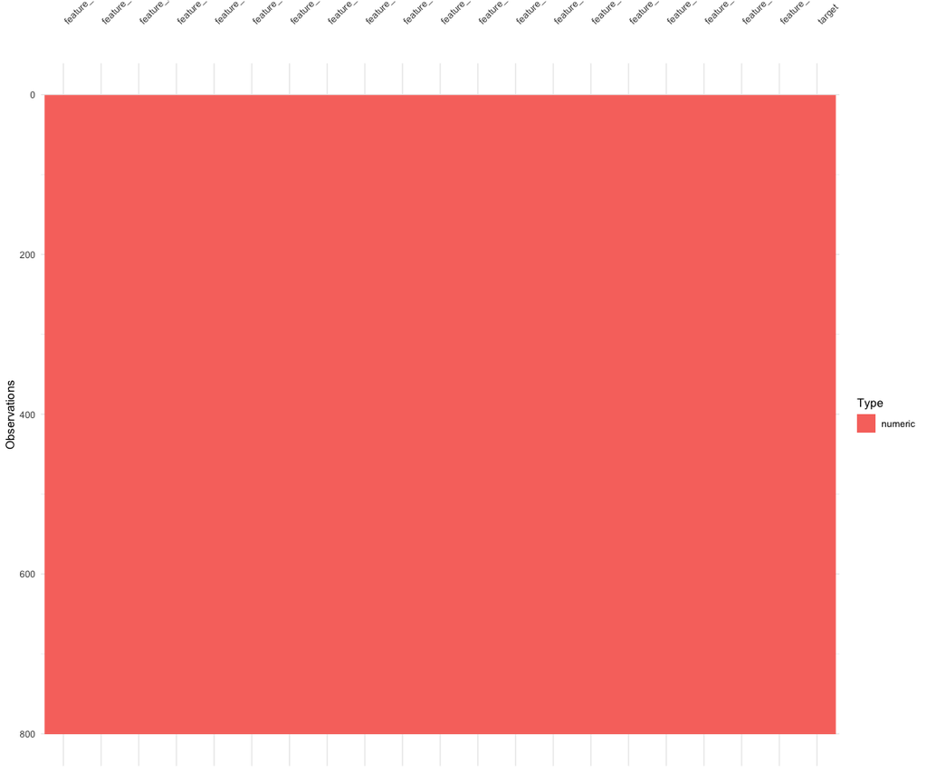

```r
# Display variable classes and missingness cues in a compact visual matrix.
vis_dat(training_data)
```

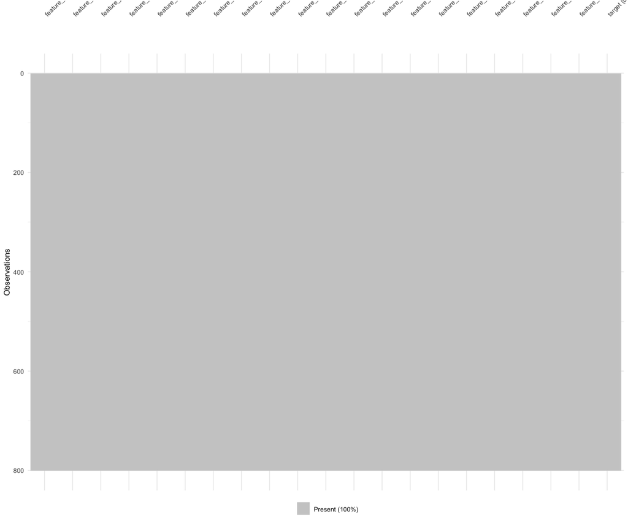

```r
# Render the global missingness pattern so gaps would be visible immediately if they existed.
vis_miss(training_data)
```

```r
# Report missing-value counts and percentages by variable in tabular form.
miss_var_summary(training_data)
```

| variable | n_miss | pct_miss |
| --- | --- | --- |
| feature_0 | 0 | 0 |
| feature_1 | 0 | 0 |
| feature_2 | 0 | 0 |
| feature_3 | 0 | 0 |
| feature_4 | 0 | 0 |
| feature_5 | 0 | 0 |
| feature_6 | 0 | 0 |
| feature_7 | 0 | 0 |
| feature_8 | 0 | 0 |
| feature_9 | 0 | 0 |

[output cut: 11 more lines]

The quality check shows that both files are complete and do not contain duplicated observations. The additional profiling output is still valuable because it documents those clean conditions explicitly and leaves the notebook ready for future file versions that might include missingness or type irregularities.

The following chunk creates that complete-case training table and stores the predictor names used repeatedly in later summaries and graphics.

```r
# Create a complete-case training table as a defensive step for later reusable analysis.
training_data_complete <- training_data |>
  drop_na()

# Save the predictor names once so later code can refer to them consistently.
feature_names <- names(training_data_complete) |> setdiff("target")
```

## 2.5) Descriptive statistics

Following the logic suggested in linear modeling workflows, the first diagnostic is to verify that both the dependent variable and the regressors have variation in the sample. Without variation in $y$ or in the $x$ variables, OLS cannot be informative.

The next chunk computes descriptive statistics for the target and all predictors. These summaries provide a first numerical view of location, spread, and range before the graphical diagnostics.

```r
# Summarize the target with basic measures of center and dispersion.
target_summary <- training_data_complete |>
  summarise(
    observations = n(),
    min = min(target),
    q1 = quantile(target, 0.25),
    median = median(target),
    mean = mean(target),
    q3 = quantile(target, 0.75),
    max = max(target),
    sd = sd(target)
  )

# Summarize each predictor and reshape the result into a long, readable table.
feature_summary <- training_data_complete |>
  summarise(
    across(all_of(feature_names), list(mean = mean, sd = sd, min = min, max = max))
  ) |>
  pivot_longer(
    everything(),
    names_to = c("feature", ".value"),
    names_pattern = "(feature_[0-9]+)_(mean|sd|min|max)"
  ) |>
  arrange(desc(sd))

target_summary
```

| observations | min | q1 | median | mean | q3 | max | sd |
| --- | --- | --- | --- | --- | --- | --- | --- |
| 800 | 0.2798048 | 10.87991 | 14.68795 | 14.63134 | 18.22471 | 27.36079 | 5.089503 |

```r
feature_summary
```

| feature | mean | sd | min | max |
| --- | --- | --- | --- | --- |
| feature_12 | 479.841915 | 276.304197 | 1.706239996 | 979.715063 |
| feature_4 | 485.975950 | 272.594030 | 0.598527375 | 950.017444 |
| feature_0 | 468.181612 | 270.797415 | 0.916647790 | 940.771543 |
| feature_19 | 457.016407 | 270.650146 | 0.252919317 | 935.740775 |
| feature_7 | 387.196289 | 235.131376 | 0.474824729 | 809.346792 |
| feature_10 | 401.079696 | 228.533579 | 1.487604576 | 767.311089 |
| feature_5 | 320.953859 | 185.157189 | 0.997347496 | 638.199832 |
| feature_2 | 317.132996 | 176.501920 | 0.173024518 | 614.271632 |
| feature_1 | 301.960218 | 170.691136 | 0.800119208 | 595.359858 |
| feature_15 | 277.205999 | 167.385930 | 1.726914654 | 566.611509 |

[output cut: 10 more lines]

## 2.6) Distribution of the target

The target distribution matters because strong skewness, heavy tails, or extreme outliers can later affect residual behavior and the stability of OLS estimates.

The next chunk plots a histogram of the target to assess its overall shape. This gives an early visual impression of skewness, concentration, and tail behavior.

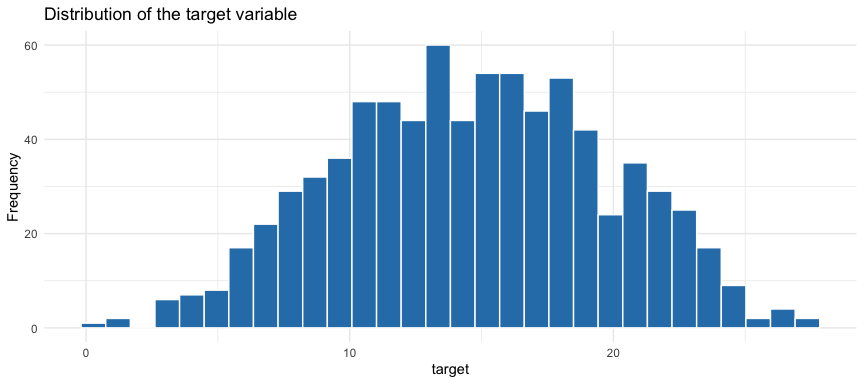

```r
# Visualize the target distribution before any model is fitted.
ggplot(training_data_complete, aes(x = target)) +
  geom_histogram(bins = 30, fill = "#2C7FB8", color = "white") +
  labs(
    title = "Distribution of the target variable",
    x = "target",
    y = "Frequency"
  )
```

This companion chunk adds a boxplot of the same variable. The boxplot is useful for quickly spotting extreme values and summarizing spread in a compact way.

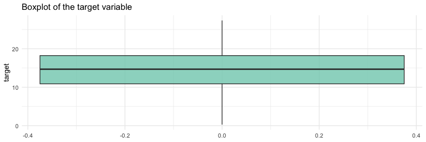

```r
# Complement the histogram with a boxplot to highlight spread and potential outliers.
ggplot(training_data_complete, aes(y = target)) +
  geom_boxplot(fill = "#7FCDBB", alpha = 0.8) +
  labs(
    title = "Boxplot of the target variable",
    x = NULL,
    y = "target"
  )
```

Additionally, the violin plot helps reveal characteristics of the distribution that may not be immediately visible in a standard boxplot, such as multimodality, asymmetry, or irregular concentration patterns. When combined with the embedded boxplot and jittered observations, the visualization provides a more comprehensive understanding of the variable’s central tendency, dispersion, and potential outliers, supporting a more robust exploratory data analysis process.

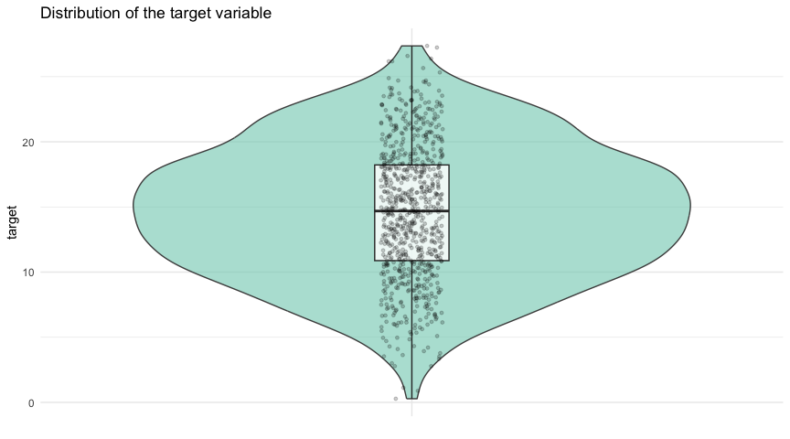

```r
ggplot(training_data_complete, aes(x = "", y = target)) +
  geom_violin(
    fill = "#7FCDBB",
    alpha = 0.6,
    color = "gray30"
  ) +
  geom_boxplot(
    width = 0.12,
    fill = "white",
    outlier.color = "red",
    alpha = 0.8
  ) +
  geom_jitter(
    width = 0.05,
    alpha = 0.2,
    size = 1
  ) +
  labs(
    title = "Distribution of the target variable",
    x = NULL,
    y = "target"
  ) +
  theme_minimal()
```

## 2.7) Distribution of the predictors

Because there are 20 continuous predictors, the most useful view is a faceted set of histograms. This allows us to identify whether the features share a comparable scale, whether some of them are highly skewed, and whether there are unusual tails that may later influence linear fits.

The following chunk reshapes the predictors into long format and draws one histogram per variable. Faceting makes it possible to compare all 20 predictors within a single consistent display.

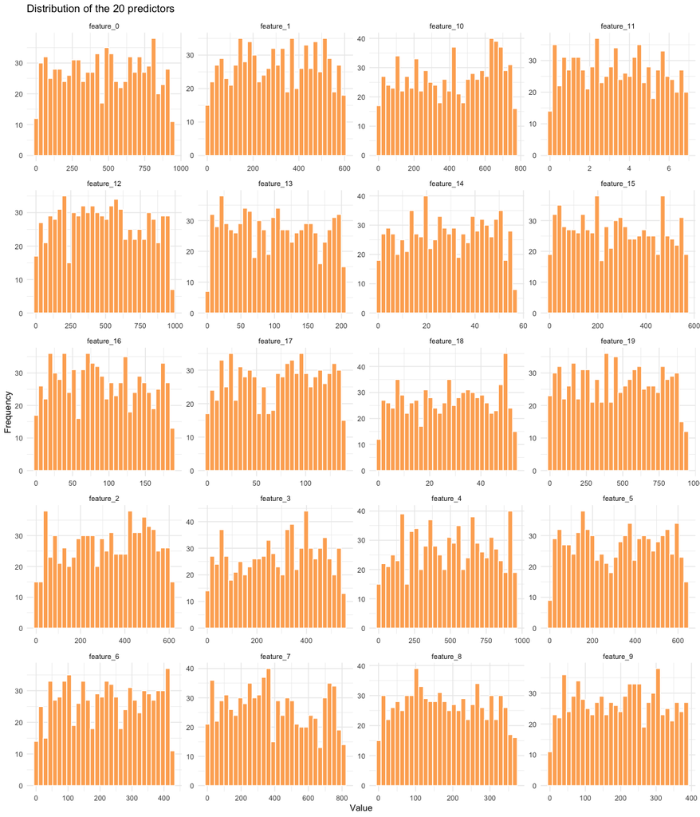

```r
# Pivot the predictors into long format so one plotting command can render all feature panels.
training_data_complete |>
  pivot_longer(
    cols = all_of(feature_names),
    names_to = "feature",
    values_to = "value"
  ) |>
  ggplot(aes(x = value)) +
  geom_histogram(bins = 30, fill = "#FDAE61", color = "white") +
  facet_wrap(~ feature, scales = "free", ncol = 4) +
  labs(
    title = "Distribution of the 20 predictors",
    x = "Value",
    y = "Frequency"
  )
```

The next chunk complements the histograms with faceted boxplots. This second view is especially useful for comparing spread and identifying potential outliers across predictors.

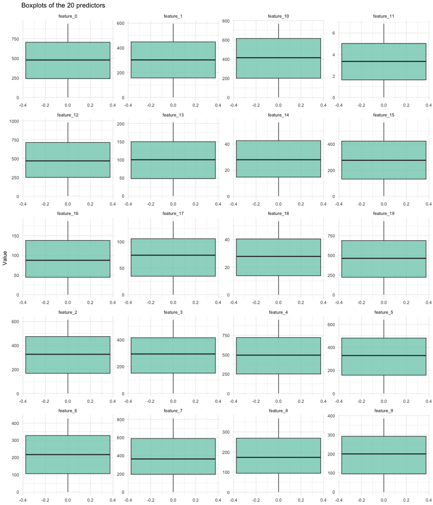

```r
# Use faceted boxplots to compare dispersion and outlier behavior across predictors.
training_data_complete |>
  pivot_longer(
    cols = all_of(feature_names),
    names_to = "feature",
    values_to = "value"
  ) |>
  ggplot(aes(y = value)) +
  geom_boxplot(fill = "#7FCDBB", alpha = 0.8, outlier.alpha = 0.35) +
  facet_wrap(~ feature, scales = "free", ncol = 4) +
  labs(
    title = "Boxplots of the 20 predictors",
    x = NULL,
    y = "Value"
  )
```

## 2.8) Relationship between each predictor and the target

Before fitting a full model, it is useful to look at the bivariate relationship between each predictor and the target.

The next chunk computes the Pearson correlation between each predictor and the target, then ranks predictors by the absolute strength of their marginal association.

```r
# Rank predictors by their marginal correlation with the target.
correlation_with_target <- tibble(
  feature = feature_names,
  correlation = map_dbl(
    feature_names,
    ~ cor(training_data_complete[[.x]], training_data_complete$target)
  )
) |>
  mutate(abs_correlation = abs(correlation)) |>
  arrange(desc(abs_correlation))

correlation_with_target
```

| feature | correlation | abs_correlation |
| --- | --- | --- |
| feature_2 | 0.5517672784 | 0.5517672784 |
| feature_13 | 0.4046966326 | 0.4046966326 |
| feature_9 | 0.3619417998 | 0.3619417998 |
| feature_11 | 0.3228021537 | 0.3228021537 |
| feature_4 | -0.0626716230 | 0.0626716230 |
| feature_18 | 0.0600520246 | 0.0600520246 |
| feature_19 | -0.0534636570 | 0.0534636570 |
| feature_1 | -0.0471621321 | 0.0471621321 |
| feature_10 | 0.0454853661 | 0.0454853661 |
| feature_6 | 0.0444432061 | 0.0444432061 |

[output cut: 10 more lines]

This bar chart turns the ranked table into a quick visual comparison of the strongest positive and negative associations.

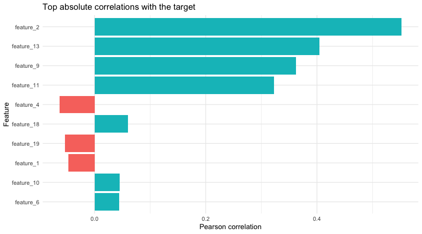

```r
# Visualize the ten strongest absolute correlations while preserving their sign.
correlation_with_target |>
  slice_head(n = 10) |>
  ggplot(aes(x = reorder(feature, abs_correlation), y = correlation, fill = correlation > 0)) +
  geom_col(show.legend = FALSE) +
  coord_flip() +
  labs(
    title = "Top absolute correlations with the target",
    x = "Feature",
    y = "Pearson correlation"
  )
```

To inspect linearity more directly, the four predictors with the strongest marginal association with the target are plotted below.

The following chunk selects those four predictors and draws scatterplots with fitted linear trends. This helps assess whether the strongest marginal signals look approximately linear.

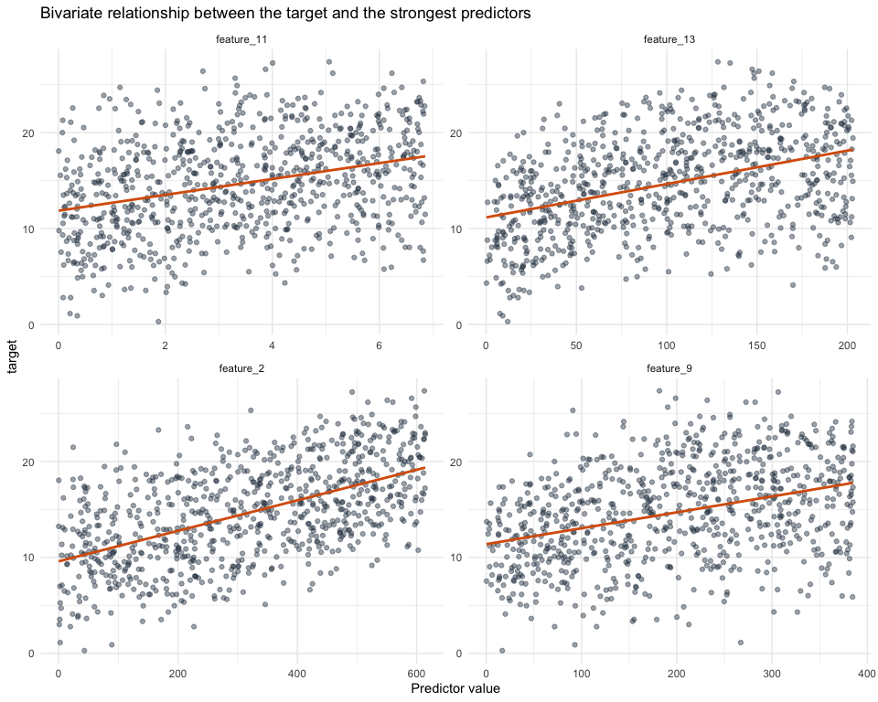

```r
# Select the strongest marginal predictors for a closer visual inspection.
top_features <- correlation_with_target |>
  slice_head(n = 4) |>
  pull(feature)

# Plot each selected predictor against the target with a linear reference line.
training_data_complete |>
  pivot_longer(
    cols = all_of(top_features),
    names_to = "feature",
    values_to = "value"
  ) |>
  ggplot(aes(x = value, y = target)) +
  geom_point(alpha = 0.45, color = "#2C3E50") +
  geom_smooth(method = "lm", se = FALSE, color = "#D95F0E") +
  facet_wrap(~ feature, scales = "free") +
  labs(
    title = "Bivariate relationship between the target and the strongest predictors",
    x = "Predictor value",
    y = "target"
  )
```

## 2.9) Correlation structure among predictors

One of the practical concerns in multiple OLS is multicollinearity. A first pass is to inspect the pairwise correlation matrix among predictors.

The next chunk computes the full predictor correlation matrix, reshapes it into a long table, and extracts the strongest non-diagonal relationships for inspection.

```r
# Build the full predictor correlation matrix as a first descriptive check for multicollinearity.
predictor_correlation_matrix <- cor(training_data_complete |> select(all_of(feature_names)))

# Convert the matrix to long format so it can be filtered, ranked, and plotted.
predictor_correlation_long <- as_tibble(
  as.data.frame(as.table(predictor_correlation_matrix), responseName = "correlation")
) |>
  rename(feature_1 = Var1, feature_2 = Var2)

max_pairwise_correlation <- predictor_correlation_long |>
  filter(feature_1 != feature_2) |>
  mutate(abs_correlation = abs(correlation)) |>
  arrange(desc(abs_correlation)) |>
  slice(1:10)

max_pairwise_correlation
```

| feature_1 | feature_2 | correlation | abs_correlation |
| --- | --- | --- | --- |
| feature_10 | feature_1 | -0.10104377 | 0.10104377 |
| feature_1 | feature_10 | -0.10104377 | 0.10104377 |
| feature_11 | feature_5 | -0.09084401 | 0.09084401 |
| feature_5 | feature_11 | -0.09084401 | 0.09084401 |
| feature_7 | feature_2 | 0.08879566 | 0.08879566 |
| feature_2 | feature_7 | 0.08879566 | 0.08879566 |
| feature_12 | feature_0 | -0.07706571 | 0.07706571 |
| feature_0 | feature_12 | -0.07706571 | 0.07706571 |
| feature_19 | feature_16 | 0.07694476 | 0.07694476 |
| feature_16 | feature_19 | 0.07694476 | 0.07694476 |

This heatmap translates the same correlation matrix into a visual diagnostic. It helps reveal clusters of related predictors more quickly than a raw numeric table.

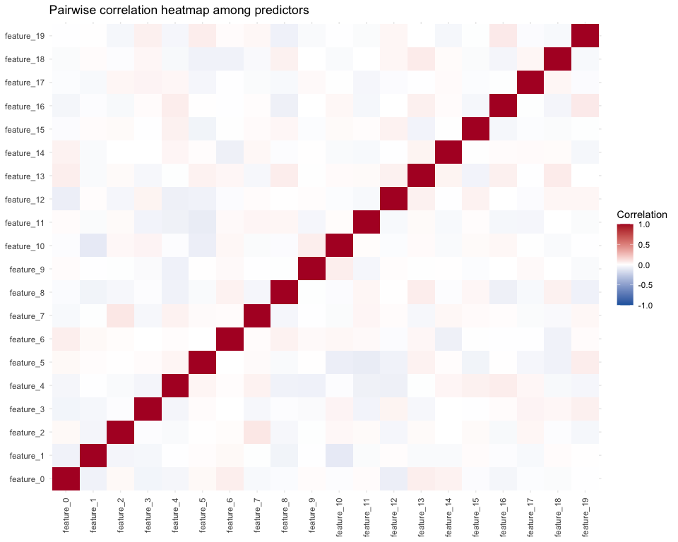

```r
# Visualize the pairwise correlation structure to spot broad dependence patterns.
predictor_correlation_long |>
  ggplot(aes(x = feature_1, y = feature_2, fill = correlation)) +
  geom_tile() +
  scale_fill_gradient2(
    low = "#2166AC",
    mid = "white",
    high = "#B2182B",
    midpoint = 0,
    limits = c(-1, 1)
  ) +
  labs(
    title = "Pairwise correlation heatmap among predictors",
    x = NULL,
    y = NULL,
    fill = "Correlation"
  ) +
  theme(axis.text.x = element_text(angle = 90, vjust = 0.5, hjust = 1))
```

## 2.10) Preliminary assessment of OLS principles

At the end of Data Understanding, we can summarize what has and has not been learned about the suitability of an OLS approach.

**What can already be supported from the data**

1. **Variation in** $y$ and in the $x$ variables: the target and all predictors vary in the sample, so estimation is possible.
2. **Numeric measurement level:** after conversion from the raw character import, all predictors and the target behave as continuous numeric variables, which is compatible with OLS.
3. **Absence of perfect multicollinearity:** the correlation matrix does not reveal redundant columns or exact linear duplication among predictors.
4. **Potential linear signal:** scatterplots show that a linear approximation can be explored, with the strongest marginal signal concentrated in a subset of predictors rather than spread uniformly across all variables.

**What cannot be confirmed yet in this phase**

1. **Exogeneity / zero conditional mean** $E(u \mid X) = 0$ cannot be verified from observational data using descriptive analysis alone. It will remain a modeling assumption.
2. **Homoscedasticity** cannot be properly evaluated without fitting a model and inspecting residuals.
3. **Normality of residuals** cannot be assessed yet because residuals do not exist before estimation.
4. **Independence of errors** also requires model-based diagnostics and stronger knowledge of the data generating process.

# 3) Data Preparation

This phase transforms the findings from Data Understanding into a model-ready dataset. The preparation logic can stay intentionally simple and transparent while remaining reusable for future model versions.

## 3.1) Preparing model-ready datasets

The preparation stage follows four practical rules:

1. Keep all original predictors.
2. Preserve the numeric representation obtained in Section 2.
3. Keep all supervised training rows because the delivered file does not contain incomplete observations.
4. Keep the blind test dataset intact so it remains ready for final scoring.

The following chunk translates those rules into model-facing datasets and companion checks. It also prepares quick summaries for row counts, predictor alignment, and simple variance screening.

```r
# Keep the full supervised training data because the integrity checks found no missing rows.
training_data_model <- training_data

# Preserve the full blind test set so it remains ready for final scoring.
blind_test_data_model <- blind_test_data

# Record the shape of the prepared datasets after the complete-case step.
model_data_summary <- tibble(
  dataset = c("training_data_model", "blind_test_data_model"),
  rows = c(nrow(training_data_model), nrow(blind_test_data_model)),
  columns = c(ncol(training_data_model), ncol(blind_test_data_model))
)

blind_feature_names <- names(blind_test_data_model)

# Check whether the predictor columns line up exactly between training and blind test data.
column_alignment <- tibble(
  training_feature_count = length(feature_names),
  blind_feature_count = length(blind_feature_names),
  same_feature_names = identical(feature_names, blind_feature_names),
  missing_in_blind = paste(setdiff(feature_names, blind_feature_names), collapse = ", "),
  extra_in_blind = paste(setdiff(blind_feature_names, feature_names), collapse = ", ")
)

# Screen predictor variability without removing columns manually at this stage.
predictor_sds <- training_data_model |>
  summarise(across(all_of(feature_names), sd)) |>
  pivot_longer(
    everything(),
    names_to = "feature",
    values_to = "sd"
  ) |>
  mutate(is_zero_variance = sd == 0)

model_data_summary
```

| dataset | rows | columns |
| --- | --- | --- |
| training_data_model | 800 | 21 |
| blind_test_data_model | 200 | 20 |

```r
column_alignment
```

| training_feature_count | blind_feature_count | same_feature_names | missing_in_blind | extra_in_blind |
| --- | --- | --- | --- | --- |
| 20 | 20 | TRUE |  |  |

## 3.2) Data quality checks carried into modeling

The next chunk brings forward the core integrity checks from the understanding phase. Keeping them visible here makes the preparation stage transparent about the quality of the current files.

```r
# Keep the core integrity checks in view before the notebook moves into modeling.
structure_check
```

| dataset | expected_rows | observed_rows | expected_feature_columns | observed_feature_columns | has_target_column |
| --- | --- | --- | --- | --- | --- |
| training_data | 800 | 800 | 20 | 20 | TRUE |
| blind_test_data | 200 | 200 | 20 | 20 | FALSE |

```r
quality_summary
```

| metric | value |
| --- | --- |
| Training rows with any missing value | 0 |
| Blind test rows with any missing value | 0 |
| Duplicated training rows | 0 |
| Duplicated blind test rows | 0 |

```r
missing_by_column
```

| variable | missing_values |
| --- | --- |

These checks are intentionally kept visible in the notebook because they document that the delivered files satisfy the expected structure and can move into modeling without manual repair.

## 3.3) Predictor alignment and variance screening

The following chunk revisits the feature alignment summary and orders predictors by their standard deviation. This provides a lightweight readiness check before recipes take over any automated preprocessing.

```r
# Reprint the alignment summary and inspect the predictor spread from lowest to highest.
column_alignment
```

| training_feature_count | blind_feature_count | same_feature_names | missing_in_blind | extra_in_blind |
| --- | --- | --- | --- | --- |
| 20 | 20 | TRUE |  |  |

```r
predictor_sds |>
  arrange(sd)
```

| feature | sd | is_zero_variance |
| --- | --- | --- |
| feature_11 | 1.986369 | FALSE |
| feature_18 | 15.509062 | FALSE |
| feature_14 | 16.105155 | FALSE |
| feature_17 | 40.588905 | FALSE |
| feature_16 | 53.950523 | FALSE |
| feature_13 | 59.149794 | FALSE |
| feature_8 | 104.059309 | FALSE |
| feature_9 | 111.042671 | FALSE |
| feature_6 | 123.660691 | FALSE |
| feature_3 | 157.698215 | FALSE |

[output cut: 10 more lines]

No predictor is removed manually here. Instead, zero-variance handling is delegated to the modeling recipe so the same code can react cleanly if a future file version changes the predictor behavior.

# 4) Modeling

The modeling stage balances interpretability and predictive performance. OLS is kept as the central baseline, but the workflow also compares regularized linear models and a tree-based method. The code is intentionally explicit, so each candidate model can be read and audited separately.

## 4.1) Train/test split and resampling

The following chunk creates the evaluation backbone of the modeling stage. It reserves a final holdout split, builds cross-validation folds from the training subset, and defines the metric bundle reused across candidate models.

```r
# Fix the random seed so the split and resampling results are reproducible.
set.seed(123)

# Reserve a final stratified holdout set while keeping most observations for model development.
data_split <- initial_split(training_data_model, prop = 0.8, strata = target)
train_data <- training(data_split)
test_data <- testing(data_split)
folds <- vfold_cv(train_data, v = 5, strata = target) # Build stratified cross-validation folds from the training split.

# Reuse the same metric bundle across all regression models for a fair comparison.
metric_set_regression <- metric_set(rmse, mae, rsq)
```

An 80/20 split was selected to preserve most observations for model training while still reserving a sufficiently large holdout set for final evaluation. Because the target is continuous, both the initial split and the resampling folds are stratified on `target` so the outcome distribution remains more stable across partitions. This follows the data-spending and resampling guidance in *Tidy Modeling with R*, where the test set is held in reserve and the training set is the substrate for model development ([splitting](https://www.tmwr.org/splitting.html), [resampling](https://www.tmwr.org/resampling.html)).

Here, the cross-validation folds are created from `train_data`, not from the full dataset, so the `test_data` remains untouched until a final workflow has already been chosen. `vfold_cv(train_data, v = 5, strata = target)` creates five stratified folds, meaning the model is fit multiple times on analysis subsets and evaluated on separate assessment subsets. This mirrors the empirical validation workflow emphasized in *Tidy Modeling with R*: resampling is used to compare candidate models, while the holdout set is reserved for one final check of the chosen winner ([resampling](https://www.tmwr.org/resampling.html), performance).

## 4.2) Baseline and recipes

This subsection separates the modeling foundation into two complementary pieces. First, it defines a naive benchmark that every trained workflow should be able to beat. Second, it formalizes the preprocessing recipes reused across model families so that each estimator can compete under the transformations that are most defensible for its learning mechanism.

### 4.2.1) Baseline

The first chunk creates a mean baseline using only the average target value from `train_data`. This reference model ignores all predictors and therefore establishes the minimum predictive standard that the supervised workflows should improve upon on the reserved holdout split.

```r
# Use the mean target value as a simple benchmark that every trained model should beat.
mean_baseline_value <- mean(train_data$target) # Get only the mean

# Table with target and mean_baseline_value
mean_baseline_predictions <- tibble(
  truth = test_data$target,
  .pred = mean_baseline_value
)


# Compute the numeric baseline metrics directly and append an explicit NA for R-squared.
mean_baseline_metrics <- bind_rows(
  yardstick::metric_set(rmse, mae)(
    mean_baseline_predictions,
    truth = truth,
    estimate = .pred
  ),
  tibble(
    .metric = "rsq",
    .estimator = "standard",
    .estimate = NA_real_
  )
) |>
  mutate(model = "mean_baseline")
```

Because the mean baseline predicts the same constant value for every observation, its `R-squared` value is expected to be `NA`. Even so, its `RMSE` and `MAE` remain useful as a transparent lower-bound benchmark for the trained models evaluated later in the notebook.

### 4.2.2) Recipes

The next chunk defines the preprocessing recipes shared across model families. The `base_recipe` only filters zero-variance predictors, the `normalized_recipe` adds scaling for models that are sensitive to predictor magnitude, and the `pca_recipe` applies unsupervised dimensionality reduction after standardization. As discussed in *Tidy Modeling with R*, these steps are part of the modeling workflow rather than a separate pre-model stage ([workflows](https://www.tmwr.org/workflows.html)). In this notebook, PCA remains a pragmatic model-dependent feature engineering option, but the retained dimensionality is fixed through the Kaiser criterion computed from the standardized `train_data`.

The model variants compared follow two methodological rules. First, no subsets supervised by the target are used at this stage; the notebook only tests workflow variants based on unsupervised preprocessing choices that can be estimated cleanly inside resampling. Second, internal variant selection is decided by cross-validation rather than by holdout performance, so the reserved test split remains available for a single final validation of the selected workflow. PCA remains a model-dependent feature engineering option, but the number of retained components is fixed by the Kaiser criterion after standardization of `train_data` as a pragmatic stability choice, even though the more consequential TMWR-aligned correction in this notebook is moving final family selection away from the holdout set ([workflows](https://www.tmwr.org/workflows.html), [resampling](https://www.tmwr.org/resampling.html)).

```r
# The base recipe only removes predictors with zero variance.
base_recipe <- recipe(target ~ ., data = train_data) |>
  step_zv(all_predictors())

# The normalized recipe adds scaling for models that are sensitive to predictor magnitude.
normalized_recipe <- recipe(target ~ ., data = train_data) |>
  step_zv(all_predictors()) |>
  step_normalize(all_predictors())

# Estimate PCA outside the recipe so the Kaiser criterion can fix the retained dimensionality.
predictor_matrix <- train_data |>
  select(-target) |>
  scale(center = TRUE, scale = TRUE)

predictor_pca_fit <- prcomp(predictor_matrix, center = FALSE, scale. = FALSE)
predictor_eigenvalues <- predictor_pca_fit$sdev^2
kaiser_num_comp <- sum(predictor_eigenvalues > 1)

pca_kaiser_summary <- tibble(
  kaiser_num_comp = kaiser_num_comp,
  total_predictors = ncol(predictor_matrix),
  variance_explained_by_retained_components =
    sum(predictor_eigenvalues[predictor_eigenvalues > 1]) / sum(predictor_eigenvalues)
)

# The PCA recipe now uses the fixed Kaiser component count after standardization.
pca_recipe <- recipe(target ~ ., data = train_data) |>
  step_zv(all_predictors()) |>
  step_normalize(all_predictors()) |>
  step_pca(all_predictors(), num_comp = kaiser_num_comp)

pca_kaiser_summary
```

| kaiser_num_comp | total_predictors | variance_explained_by_retained_components |
| --- | --- | --- |
| 10 | 20 | 0.5748443 |

To address the requirement to “select a subset of features,” this notebook evaluates PCA as a feature-reduction strategy. Strictly speaking, PCA does not select a subset of the original predictors; instead, it creates a smaller subset of transformed features called principal components. Each component is a linear combination of the original predictors and is ordered by the amount of variance it explains.

Let $X \in \mathbb{R}^{n \times p}$ be the predictor matrix. First, each predictor is standardized:

$$z_{ij} = \frac{x_{ij} -
\bar{x}_j}{s_j}$$

where $\bar{x}_j$ is the mean of predictor $j$, and $s_j$ is its standard deviation.

PCA is then applied to the standardized predictor matrix $Z$. The correlation matrix is:

$$R = \frac{1}{n - 1} Z^\top
Z$$

Principal components are obtained from the eigenvalue decomposition:

$$R v_k = \lambda_k v_k$$

where $v_k$ is the loading vector for principal component $k$, and $\lambda_k$ is the variance explained by that component.

Using the Kaiser criterion, the number of retained components is:

$$K = \sum_{k=1}^{p} \mathbf{1}(\lambda_k
> 1)$$

A component is retained only if:

$$\lambda_k > 1$$

because each standardized original feature contributes one unit of variance. Therefore, PCA is used here to evaluate a reduced feature representation while avoiding manual selection of individual predictors.

## 4.3) OLS

Ordinary Least Squares (OLS) models the target as a linear combination of the predictors,

$$y_i = \beta_0 + \beta_1 x_{i1} + \beta_2
x_{i2} + \cdots + \beta_p x_{ip} + \varepsilon_i,$$

and estimates the coefficient vector by minimizing the residual sum of squares,

$$\min_{\beta_0,\boldsymbol{\beta}}
\sum_{i=1}^{n} \left(y_i - \beta_0 - \mathbf{x}_i^\top
\boldsymbol{\beta}\right)^2.$$

This makes OLS the most direct linear benchmark in the notebook: it preserves a fully interpretable relationship between predictors and response, and it also provides the classical regression reference used later for residual diagnostics and assumption checks.

OLS was considered because the challenge involves a continuous target and entirely numerical predictors, so a linear baseline is both natural and informative. Even if a more flexible model eventually wins, OLS helps quantify how much predictive signal can be captured by a simple additive structure and serves as a transparent benchmark against which more complex methods can justify their added complexity.

### 4.3.1) OLS with original predictors

The first OLS variant uses the original predictors after only removing zero-variance columns. This is the most direct specification and serves as the baseline linear workflow within the OLS family.

```r
# Define the OLS workflow that keeps the original predictor space.
ols_raw_workflow <- workflow() |>
  add_recipe(base_recipe) |>
  add_model(linear_reg() |> set_engine("lm"))

# Estimate the raw OLS workflow under cross-validation.
ols_raw_resamples <- fit_resamples(
  object = ols_raw_workflow,
  resamples = folds,
  metrics = metric_set_regression,
  control = control_resamples(save_pred = TRUE)
)
```

### 4.3.2) OLS with PCA-based feature engineering

The second OLS variant applies PCA after normalization so the linear model can be evaluated on a reduced feature space. This follows the workflow-based preprocessing logic recommended in *Tidy Modeling with R*, where feature engineering is estimated only from the training data inside resampling. In this notebook, the PCA dimensionality is fixed using the Kaiser criterion computed from the standardized predictor space.

```r
# Define the OLS workflow that uses PCA-based feature engineering.
ols_pca_workflow <- workflow() |>
  add_recipe(pca_recipe) |>
  add_model(linear_reg() |> set_engine("lm"))

# Estimate the PCA-enhanced OLS workflow under cross-validation.
ols_pca_resamples <- fit_resamples(
  object = ols_pca_workflow,
  resamples = folds,
  metrics = metric_set_regression,
  control = control_resamples(save_pred = TRUE)
)
```

### 4.3.3) OLS variant selection

The next chunk compares the raw and PCA-based OLS workflows using cross-validated RMSE, selects the best OLS variant, and then fits that workflow on the full prepared training data for later reuse. Following the *Tidy Modeling with R* resampling workflow, the holdout set is not used at this stage.

```r
# Collect the candidate OLS variants in a single object for internal comparison.
ols_variant_resamples <- bind_rows(
  collect_metrics(ols_raw_resamples) |>
    mutate(model = "ols", variant = "raw"),
  collect_metrics(ols_pca_resamples) |>
    mutate(model = "ols", variant = "pca")
)

# Rank OLS variants by cross-validated RMSE so only the winner reaches the holdout set.
ols_variant_leaderboard <- ols_variant_resamples |>
  filter(.metric == "rmse") |>
  arrange(mean) |>
  select(model, variant, .metric, mean, std_err)

ols_best_variant_name <- ols_variant_leaderboard |>
  slice(1) |>
  pull(variant)

# Map the winning OLS variant back to a workflow object that can be finalized and evaluated.
if (ols_best_variant_name == "raw") {
  ols_best_workflow <- ols_raw_workflow
} else {
  ols_best_workflow <- ols_pca_workflow
}

ols_resample_metrics <- ols_variant_resamples

# Fit the winning OLS workflow on the full prepared training data for later reuse.
ols_fitted_workflow <- fit(ols_best_workflow, data = training_data_model)

ols_variant_leaderboard
```

| model | variant | .metric | mean | std_err |
| --- | --- | --- | --- | --- |
| ols | raw | rmse | 2.845045 | 0.08680131 |
| ols | pca | rmse | 4.026585 | 0.10663905 |

We filter by rmse in all variant-selection steps because this project needs **one single primary criterion** to rank competing workflows consistently, and RMSE is a strong default choice for regression when the goal is predictive accuracy. RMSE measures the typical size of prediction errors on the same scale as the target, so it is easy to interpret, directly comparable across models, and it penalizes large mistakes more heavily than MAE, which is useful when we want to discourage models that occasionally miss by a lot. The notebook still computes other metrics like MAE and R², but those are used as complementary diagnostics; if we mixed metrics when selecting variants, the ranking could become inconsistent or ambiguous. So the code filters to RMSE because RMSE is the predefined selection metric used to decide which variant wins within each model family and which family wins overall.

## 4.4) Ridge

Ridge regression keeps the same linear predictor as OLS but adds an $L_2$ penalty that shrinks coefficients toward zero,

$$\min_{\beta_0,\boldsymbol{\beta}}
\sum_{i=1}^{n} \left(y_i - \beta_0 - \mathbf{x}_i^\top
\boldsymbol{\beta}\right)^2 + \lambda \sum_{j=1}^{p}
\beta_j^2,$$

where $\lambda \ge 0$ controls the strength of regularization. The penalty does not remove predictors entirely, but it reduces coefficient magnitude and can stabilize estimation when predictors are correlated or when the unregularized linear fit is too variable.

Ridge was considered because this challenge includes many numerical predictors that may share overlapping information. It offers a conservative extension of OLS: if multicollinearity or coefficient instability harms generalization, ridge can improve predictive performance while preserving the overall linear structure of the model.

### 4.4.1) Ridge with normalized predictors

The first ridge variant uses normalized predictors without changing the dimensionality of the feature space. This is the standard preprocessing path for a scale-sensitive regularized linear model.

```r
# Ridge shrinks coefficients continuously while keeping all predictors in the model.
ridge_norm_workflow <- workflow() |>
  add_recipe(normalized_recipe) |>
  add_model(
    linear_reg(
      penalty = tune(), # regularization strength is not fixed yet
      mixture = 0 #This is what makes the model ridge.
      ) |>
      set_engine("glmnet")
  )

# Search over a regular grid of candidate penalty values.
ridge_grid <- grid_regular(
  penalty(), # try different amounts of shrinkage.
  levels = 6 # generate 6 candidate values for the penalty
)

# Tune ridge with normalized predictors using cross-validation.
ridge_norm_tune <- tune_grid(
  object = ridge_norm_workflow,
  resamples = folds,
  grid = ridge_grid,
  metrics = metric_set_regression,
  control = control_grid(save_pred = TRUE)
)
```

This code builds and tunes a **ridge regression** workflow using normalized predictors. First, ridge_norm_workflow combines the normalized_recipe with a linear regression model fitted through glmnet, where mixture = 0 tells glmnet to use pure ridge regularization and penalty = tune() means the strength of that regularization will be chosen automatically rather than fixed in advance. Then ridge_grid <- grid_regular(penalty(), levels = 6) creates a small grid of six candidate penalty values to try. Finally, tune_grid(…) runs that ridge workflow across the cross-validation folds stored in folds, evaluates each candidate penalty with the regression metrics defined earlier, and saves the fold-level predictions. In short, this chunk tests how much coefficient shrinkage helps ridge perform on unseen data and finds the penalty value that gives the best cross-validated results.

### 4.4.2) Ridge with normalized PCA predictors

The second ridge variant combines normalization with PCA so the model can be evaluated on a reduced feature basis. This provides a conservative way to test feature engineering without using supervised subsets, while keeping the PCA dimensionality fixed by the Kaiser criterion after standardization.

```r
# Define the ridge workflow that combines normalization and PCA.
ridge_pca_workflow <- workflow() |>
  add_recipe(pca_recipe) |>
  add_model(
    linear_reg(penalty = tune(), mixture = 0) |>
      set_engine("glmnet")
  )

# Search over a smaller penalty grid while keeping the PCA dimensionality fixed.
ridge_pca_grid <- grid_regular(
  penalty(),
  levels = 4
)

# Tune ridge with PCA-based features using cross-validation.
ridge_pca_tune <- tune_grid(
  object = ridge_pca_workflow,
  resamples = folds,
  grid = ridge_pca_grid,
  metrics = metric_set_regression,
  control = control_grid(save_pred = TRUE)
)
```

### 4.4.3) Ridge variant selection

The following chunk selects the best ridge variant by cross-validated RMSE and then fits it on the full prepared training data. The reserved holdout split remains untouched until the notebook has already chosen a final family winner.

```r
# Combine ridge variants into a single leaderboard for internal comparison.
ridge_variant_resamples <- bind_rows(
  collect_metrics(ridge_norm_tune) |>
    mutate(model = "ridge", variant = "normalized"),
  collect_metrics(ridge_pca_tune) |>
    mutate(model = "ridge", variant = "pca")
)

# Rank ridge variants by cross-validated RMSE.
ridge_variant_leaderboard <- ridge_variant_resamples |>
  filter(.metric == "rmse") |>
  group_by(model, variant) |>
  slice_min(order_by = mean, n = 1, with_ties = FALSE) |>
  ungroup() |>
  arrange(mean) |>
  select(model, variant, .metric, mean, std_err, .config)

ridge_best_variant_name <- ridge_variant_leaderboard |>
  slice(1) |>
  pull(variant)

# Finalize the winning ridge workflow before holdout evaluation.
if (ridge_best_variant_name == "normalized") {
  ridge_best_params <- select_best(ridge_norm_tune, metric = "rmse")
  ridge_best_workflow <- finalize_workflow(ridge_norm_workflow, ridge_best_params)
} else {
  ridge_best_params <- select_best(ridge_pca_tune, metric = "rmse")
  ridge_best_workflow <- finalize_workflow(ridge_pca_workflow, ridge_best_params)
}

ridge_resample_metrics <- ridge_variant_resamples

# Fit the winning ridge workflow on the full prepared training data.
ridge_fitted_workflow <- fit(ridge_best_workflow, data = training_data_model)

ridge_variant_leaderboard
```

| model | variant | .metric | mean | std_err | .config |
| --- | --- | --- | --- | --- | --- |
| ridge | normalized | rmse | 2.848861 | 0.08474115 | pre0_mod1_post0 |
| ridge | pca | rmse | 4.029279 | 0.10445842 | pre0_mod1_post0 |

We filter by rmse in all variant-selection steps because this project needs **one single primary criterion** to rank competing workflows consistently, and RMSE is a strong default choice for regression when the goal is predictive accuracy. RMSE measures the typical size of prediction errors on the same scale as the target, so it is easy to interpret, directly comparable across models, and it penalizes large mistakes more heavily than MAE, which is useful when we want to discourage models that occasionally miss by a lot. The notebook still computes other metrics like MAE and R², but those are used as complementary diagnostics; if we mixed metrics when selecting variants, the ranking could become inconsistent or ambiguous. So the code filters to RMSE because RMSE is the predefined selection metric used to decide which variant wins within each model family and which family wins overall.

## 4.5) Lasso

Lasso regression also starts from a linear predictor, but replaces the $L_2$ penalty with an $L_1$ penalty,

$$\min_{\beta_0,\boldsymbol{\beta}}
\sum_{i=1}^{n} \left(y_i - \beta_0 - \mathbf{x}_i^\top
\boldsymbol{\beta}\right)^2 + \lambda \sum_{j=1}^{p}
|\beta_j|.$$

Because the $L_1$ penalty can drive some coefficients exactly to zero, lasso performs shrinkage and embedded variable selection at the same time. This makes it especially useful when the model may benefit from a sparser representation than the full predictor set.

Lasso was considered because the challenge explicitly invites discussion of feature selection, and lasso provides a principled way to test that idea without dropping predictors manually before modeling. In this notebook, it serves as a regularized linear competitor that can reveal whether a simpler predictive structure improves out-of-sample accuracy.

### 4.5.1) Lasso with normalized predictors

The first lasso variant uses normalized predictors and lets the L1 penalty decide how aggressively coefficients should be shrunk toward zero.

```r
# Lasso uses pure L1 regularization and can produce sparse coefficient patterns.
lasso_norm_workflow <- workflow() |>
  add_recipe(normalized_recipe) |>
  add_model(
    linear_reg(penalty = tune(), mixture = 1) |>
      set_engine("glmnet")
  )

# Search over a regular grid of candidate penalty values for the lasso model.
lasso_grid <- grid_regular(
  penalty(),
  levels = 6
)

# Tune lasso with normalized predictors using cross-validation.
lasso_norm_tune <- tune_grid(
  object = lasso_norm_workflow,
  resamples = folds,
  grid = lasso_grid,
  metrics = metric_set_regression,
  control = control_grid(save_pred = TRUE)
)
```

### 4.5.2) Lasso with normalized PCA predictors

The second lasso variant evaluates whether a reduced PCA representation can outperform the full normalized predictor space under the same L1 regularization logic. The retained PCA dimensionality is fixed in advance using the Kaiser criterion on the standardized training predictors.

```r
# Define the lasso workflow that combines normalization and PCA.
lasso_pca_workflow <- workflow() |>
  add_recipe(pca_recipe) |>
  add_model(
    linear_reg(penalty = tune(), mixture = 1) |>
      set_engine("glmnet")
  )

# Search over a compact penalty grid while keeping the PCA dimensionality fixed.
lasso_pca_grid <- grid_regular(
  penalty(),
  levels = 4
)

# Tune lasso with PCA-based features using cross-validation.
lasso_pca_tune <- tune_grid(
  object = lasso_pca_workflow,
  resamples = folds,
  grid = lasso_pca_grid,
  metrics = metric_set_regression,
  control = control_grid(save_pred = TRUE)
)
```

### 4.5.3) Lasso variant selection

The following chunk compares the lasso variants using cross-validated RMSE and then refits the winning workflow on the full prepared training data. As recommended in *Tidy Modeling with R*, the holdout set is still kept outside the family-selection process.

```r
# Combine lasso variants into a single resampling summary.
lasso_variant_resamples <- bind_rows(
  collect_metrics(lasso_norm_tune) |>
    mutate(model = "lasso", variant = "normalized"),
  collect_metrics(lasso_pca_tune) |>
    mutate(model = "lasso", variant = "pca")
)

# Rank lasso variants by cross-validated RMSE.
lasso_variant_leaderboard <- lasso_variant_resamples |>
  filter(.metric == "rmse") |>
  group_by(model, variant) |>
  slice_min(order_by = mean, n = 1, with_ties = FALSE) |>
  ungroup() |>
  arrange(mean) |>
  select(model, variant, .metric, mean, std_err, .config)

lasso_best_variant_name <- lasso_variant_leaderboard |>
  slice(1) |>
  pull(variant)

# Finalize the winning lasso workflow before holdout evaluation.
if (lasso_best_variant_name == "normalized") {
  lasso_best_params <- select_best(lasso_norm_tune, metric = "rmse")
  lasso_best_workflow <- finalize_workflow(lasso_norm_workflow, lasso_best_params)
} else {
  lasso_best_params <- select_best(lasso_pca_tune, metric = "rmse")
  lasso_best_workflow <- finalize_workflow(lasso_pca_workflow, lasso_best_params)
}

lasso_resample_metrics <- lasso_variant_resamples

# Fit the winning lasso workflow on the full prepared training data.
lasso_fitted_workflow <- fit(lasso_best_workflow, data = training_data_model)

lasso_variant_leaderboard
```

| model | variant | .metric | mean | std_err | .config |
| --- | --- | --- | --- | --- | --- |
| lasso | normalized | rmse | 2.840765 | 0.08696572 | pre0_mod5_post0 |
| lasso | pca | rmse | 4.026623 | 0.10645191 | pre0_mod1_post0 |

We filter by rmse in all variant-selection steps because this project needs **one single primary criterion** to rank competing workflows consistently, and RMSE is a strong default choice for regression when the goal is predictive accuracy. RMSE measures the typical size of prediction errors on the same scale as the target, so it is easy to interpret, directly comparable across models, and it penalizes large mistakes more heavily than MAE, which is useful when we want to discourage models that occasionally miss by a lot. The notebook still computes other metrics like MAE and R², but those are used as complementary diagnostics; if we mixed metrics when selecting variants, the ranking could become inconsistent or ambiguous. So the code filters to RMSE because RMSE is the predefined selection metric used to decide which variant wins within each model family and which family wins overall.

## 4.6) Elastic Net

Elastic net combines the ridge and lasso penalties in a single objective,

$$\min_{\beta_0,\boldsymbol{\beta}}
\sum_{i=1}^{n} \left(y_i - \beta_0 - \mathbf{x}_i^\top
\boldsymbol{\beta}\right)^2 + \lambda
\left[(1-\alpha)\frac{1}{2}\sum_{j=1}^{p}\beta_j^2 + \alpha
\sum_{j=1}^{p}|\beta_j|\right],$$

where $\lambda$ controls the overall regularization strength and $\alpha \in [0,1]$ controls the balance between ridge-like and lasso-like behavior. When predictors are correlated, this blended penalty can produce a more stable compromise than either pure ridge or pure lasso alone.

Elastic net was considered because it provides a flexible middle ground between coefficient shrinkage and sparsity. In a multivariate regression challenge like this one, that flexibility is valuable: if the data benefit from some variable selection but also contain correlated predictors, elastic net can adapt more naturally than the pure penalized alternatives.

### 4.6.1) Elastic net with normalized predictors

The first elastic net variant uses normalized predictors and tunes both the penalty magnitude and the balance between L1 and L2 regularization.

```r
# Elastic net tunes both shrinkage intensity and the blend of L1 and L2 penalties.

# mixture = 0 means pure ridge
# mixture = 1 means pure lasso
# values between 0 and 1 mean elastic net
enet_norm_workflow <- workflow() |>
  add_recipe(normalized_recipe) |>
  add_model(
    linear_reg(
      penalty = tune(), # regularization strength is not fixed yet
      mixture = tune() # penalty blend is also unknown and should be tuned.
      ) |>
      set_engine("glmnet")
  )

# “We do not yet know how strong the regularization should be, or how much it should behave like ridge versus lasso. We will try different combinations later.”

# Search over a two-dimensional grid of penalty and mixture values.
elastic_net_grid <- grid_regular(
  penalty(), # test several possible penalty values.
  mixture(), # test several possible mixture values.
  levels = 4 # how many values to generate along each tuning dimension.
)

# Tune elastic net with normalized predictors using cross-validation.
enet_norm_tune <- tune_grid(
  object = enet_norm_workflow,
  resamples = folds,
  grid = elastic_net_grid,
  metrics = metric_set_regression,
  control = control_grid(save_pred = TRUE)
)
```

### 4.6.2) Elastic net with normalized PCA predictors

The second elastic net variant adds PCA-based feature engineering so the model can be tested on a reduced normalized predictor space. As in the other PCA branches, the retained dimensionality is fixed by the Kaiser criterion after standardization rather than tuned inside resampling.

```r
# Define the elastic net workflow that combines normalization and PCA.
enet_pca_workflow <- workflow() |>
  add_recipe(pca_recipe) |>
  add_model(
    linear_reg(penalty = tune(), mixture = tune()) |>
      set_engine("glmnet")
  )

# Search over a compact penalty-mixture grid while keeping the PCA dimensionality fixed.
enet_pca_grid <- grid_regular(
  penalty(),
  mixture(),
  levels = 3
)

# Tune the PCA-based elastic net workflow using cross-validation.
enet_pca_tune <- tune_grid(
  object = enet_pca_workflow,
  resamples = folds,
  grid = enet_pca_grid,
  metrics = metric_set_regression,
  control = control_grid(save_pred = TRUE)
)
```

### 4.6.3) Elastic net variant selection

The next chunk compares the elastic net variants by cross-validated RMSE and then fits the best workflow on the full prepared training data. The holdout split is intentionally deferred so the final family choice remains resampling-based.

```r
# Combine elastic net variants into a single resampling summary.
elastic_net_variant_resamples <- bind_rows(
  collect_metrics(enet_norm_tune) |>
    mutate(model = "elastic_net", variant = "normalized"),
  collect_metrics(enet_pca_tune) |>
    mutate(model = "elastic_net", variant = "pca")
)

# Rank elastic net variants by cross-validated RMSE.
elastic_net_variant_leaderboard <- elastic_net_variant_resamples |>
  filter(.metric == "rmse") |>
  group_by(model, variant) |>
  slice_min(order_by = mean, n = 1, with_ties = FALSE) |>
  ungroup() |>
  arrange(mean) |>
  select(model, variant, .metric, mean, std_err, .config)

elastic_net_best_variant_name <- elastic_net_variant_leaderboard |>
  slice(1) |>
  pull(variant)

# Finalize the winning elastic net workflow before holdout evaluation.
if (elastic_net_best_variant_name == "normalized") {
  elastic_net_best_params <- select_best(enet_norm_tune, metric = "rmse")
  elastic_net_best_workflow <- finalize_workflow(enet_norm_workflow, elastic_net_best_params)
} else {
  elastic_net_best_params <- select_best(enet_pca_tune, metric = "rmse")
  elastic_net_best_workflow <- finalize_workflow(enet_pca_workflow, elastic_net_best_params)
}

elastic_net_resample_metrics <- elastic_net_variant_resamples

# Fit the winning elastic net workflow on the full prepared training data.
elastic_net_fitted_workflow <- fit(elastic_net_best_workflow, data = training_data_model)

elastic_net_variant_leaderboard
```

| model | variant | .metric | mean | std_err | .config |
| --- | --- | --- | --- | --- | --- |
| elastic_net | normalized | rmse | 2.842309 | 0.08694921 | pre0_mod04_post0 |
| elastic_net | pca | rmse | 4.026623 | 0.10645191 | pre0_mod3_post0 |

We filter by rmse in all variant-selection steps because this project needs **one single primary criterion** to rank competing workflows consistently, and RMSE is a strong default choice for regression when the goal is predictive accuracy. RMSE measures the typical size of prediction errors on the same scale as the target, so it is easy to interpret, directly comparable across models, and it penalizes large mistakes more heavily than MAE, which is useful when we want to discourage models that occasionally miss by a lot. The notebook still computes other metrics like MAE and R², but those are used as complementary diagnostics; if we mixed metrics when selecting variants, the ranking could become inconsistent or ambiguous. So the code filters to RMSE because RMSE is the predefined selection metric used to decide which variant wins within each model family and which family wins overall.

## 4.7) Random Forest

Random forest is a nonlinear ensemble model that averages the predictions of many decision trees. If $T_b(\mathbf{x})$ denotes the prediction of tree $b$, the forest prediction can be written as

$$\hat{f}(\mathbf{x}) = \frac{1}{B}
\sum_{b=1}^{B} T_b(\mathbf{x}),$$

where each tree is grown on a bootstrap sample and each split is chosen from a random subset of predictors. In regression settings, the split selection rule is typically based on reducing residual sum of squares within the child nodes, so the ensemble can capture nonlinear patterns and predictor interactions that linear models cannot represent directly.

Random forest was considered because the challenge is predictive in nature and the target may depend on interactions or nonlinear effects that are not well approximated by a purely linear form. It also provides a strong low-preprocessing benchmark: if the signal in the data is more flexible than additive linear structure, random forest is a natural candidate to capture that complexity.

### 4.7.1) Random forest with minimal preprocessing

The random forest family is treated as a methodological exception. According to *Tidy Modeling with R*, tree-based models typically require very little preprocessing, so this notebook does not force additional feature-engineering variants for random forest. Instead, the competition within this family is limited to tuning its own hyperparameters.

**First**, Define a valid tuning range for the forest hyperparameters given the available predictors.

```r
random_forest_parameters <- parameters(
  mtry(
    range = c(
      1L, # the minimum possible mtry is 1
      max(
        1L, # safety guard to make sure the upper bound never becomes less than 1
        ncol(train_data) - 1L # he maximum possible mtry is 20 (Without target)
        )
      )
    ),
  min_n()
) |>
  finalize(select(train_data, -target)) # keeps only the predictor columns and removes the target.
```

In random forest, mtry is the number of predictors randomly considered at each split in each tree. This affects how diverse the trees are and how much flexibility the model has. Conceptually:

- small mtry = each split sees fewer candidate variables
- large mtry = each split sees more candidate variables

min_n is the minimum number of observations required in a node for the tree to keep splitting. So min_n controls how detailed or how restrained the trees can become. Conceptually:

- small min_n = trees can grow deeper and become more complex
- large min_n = trees stop earlier and become simpler

**Second**, Build the random forest workflow with the base recipe because trees do not require normalization.

```r
random_forest_workflow <- workflow() |>
  add_recipe(base_recipe) |>
  add_model(
    rand_forest(
      mtry = tune(),
      min_n = tune(),
      trees = 300
    ) |>
      set_mode("regression") |>
      set_engine("ranger", importance = "impurity")
  )
```

This code creates a tidymodels workflow for a **random forest regression** model by combining preprocessing and model definition in one pipeline. workflow() starts the pipeline, add_recipe(base_recipe) adds the basic preprocessing recipe, which in this project keeps preprocessing minimal because tree-based models do not need normalization, and add_model(…) attaches a random forest specified with rand_forest(). Inside that model, mtry = tune() and min_n = tune() mean those two hyperparameters will be selected later through tuning, while trees = 300 fixes the forest size at 300 trees. Then set_mode(“regression”) tells the model this is a continuous-target prediction task, and set_engine(“ranger”, importance = “impurity”) tells tidymodels to fit the forest using the ranger package and also compute impurity-based variable importance. In plain English, this workflow says: “take the data, apply the base preprocessing, fit a 300-tree random forest for regression with ranger, and later tune the best values for mtry and min_n.

**Third**, Keep the search grid compact so the notebook remains reasonably fast to rerun.

```r
random_forest_grid <- grid_regular(
  random_forest_parameters,
  levels = 2
) |>
  slice_head(n = 6)
```

This code builds the set of random-forest hyperparameter combinations that will be tested during tuning. grid_regular(random_forest_parameters, levels = 2) creates a regular tuning grid from the parameter set defined earlier, which includes mtry and min_n, and levels = 2 means it generates a small number of candidate values along each parameter dimension rather than a dense search. Then slice_head(n = 6) keeps only the first 6 combinations, making the grid intentionally compact so the notebook stays reasonably fast to rerun. In plain English, this line says: “create a small, structured list of possible mtry and min_n settings for the random forest, and keep only a few combinations to test.”

**Fourth**, Tune the forest hyperparameters with cross-validation.

```r
random_forest_tune <- tune_grid(
  object = random_forest_workflow,
  resamples = folds,
  grid = random_forest_grid,
  metrics = metric_set_regression,
  control = control_grid(save_pred = TRUE)
)
```

This code runs the actual hyperparameter tuning for the random forest workflow using cross-validation. tune_grid() takes the workflow stored in random_forest_workflow, fits it repeatedly across the cross-validation splits stored in folds, and evaluates every hyperparameter combination listed in random_forest_grid. The argument metrics = metric_set_regression tells it to compute the regression performance measures defined earlier, such as RMSE, MAE, and R², and control = control_grid(save_pred = TRUE) tells it to save the fold-level predictions for later inspection or diagnostics. In plain English, this line says: “test each candidate random-forest configuration across the cross-validation folds, measure how well each one predicts unseen validation data, and store the results so the best forest can be selected later.

### 4.7.2) Random forest variant selection

The following chunk finalizes the tuned random forest and fits the winning tree-based workflow on the full prepared training data. The holdout split is still kept in reserve so that a single final workflow can be validated later with `last_fit()`.

```r
# Finalize the random forest workflow with the hyperparameters that minimize RMSE.
random_forest_best_params <- select_best(random_forest_tune, metric = "rmse")

random_forest_best_workflow <- finalize_workflow(
  random_forest_workflow,
  random_forest_best_params
)

random_forest_best_variant_name <- "minimal_preprocessing"

random_forest_resample_metrics <- collect_metrics(random_forest_tune) |>
  mutate(model = "random_forest", variant = random_forest_best_variant_name)

random_forest_variant_leaderboard <- random_forest_resample_metrics |>
  filter(.metric == "rmse") |>
  arrange(mean) |>
  slice(1) |>
  select(model, variant, .metric, mean, std_err, .config)

# Fit the finalized forest on the full prepared training data.
random_forest_fitted_workflow <- fit(random_forest_best_workflow, data = training_data_model)
```

We filter by rmse in all variant-selection steps because this project needs **one single primary criterion** to rank competing workflows consistently, and RMSE is a strong default choice for regression when the goal is predictive accuracy. RMSE measures the typical size of prediction errors on the same scale as the target, so it is easy to interpret, directly comparable across models, and it penalizes large mistakes more heavily than MAE, which is useful when we want to discourage models that occasionally miss by a lot. The notebook still computes other metrics like MAE and R², but those are used as complementary diagnostics; if we mixed metrics when selecting variants, the ranking could become inconsistent or ambiguous. So the code filters to RMSE because RMSE is the predefined selection metric used to decide which variant wins within each model family and which family wins overall.

## 4.8) Model comparison

### 4.8.1) Family winners entering the final comparison

The next chunk consolidates the internal leaderboards produced by every model family, assembles `training_results`, creates a cross-validated family ranking, determines `best_model_name`, and maps that winner to both a holdout-validation workflow and a deployment workflow. This follows the *Tidy Modeling with R* pattern in which resampling determines the preferred model family and `last_fit()` is reserved for one final evaluation of the chosen workflow ([workflows](https://www.tmwr.org/workflows.html), tuning).

```r
# Collect the internal variant leaderboards identified inside each model family.
variant_leaderboards <- bind_rows(
  ols_variant_leaderboard,
  ridge_variant_leaderboard,
  lasso_variant_leaderboard,
  elastic_net_variant_leaderboard,
  random_forest_variant_leaderboard
)

# Extract the best resampling result from each family so the final comparison is CV-based.
family_cv_leaderboard <- bind_rows(
  ols_variant_leaderboard |> slice(1),
  ridge_variant_leaderboard |> slice(1),
  lasso_variant_leaderboard |> slice(1),
  elastic_net_variant_leaderboard |> slice(1),
  random_forest_variant_leaderboard |> slice(1)
) |>
  arrange(mean)

# Combine the detailed resample metrics and the family-level CV ranking into a single reporting object.
training_results <- list(
  resample_metrics = bind_rows(
    ols_resample_metrics,
    ridge_resample_metrics,
    lasso_resample_metrics,
    elastic_net_resample_metrics,
    random_forest_resample_metrics
  ),
  variant_leaderboards = variant_leaderboards,
  family_cv_leaderboard = family_cv_leaderboard
)

# Alias the family-level CV ranking so downstream reporting stays simple.
leaderboard <- training_results$family_cv_leaderboard

best_model_name <- leaderboard |>
  slice(1) |>
  pull(model)

# Keep the selected variant label available for holdout reporting and deployment handoff.
best_model_variant <- leaderboard |>
  slice(1) |>
  pull(variant)

# Map the best family name back to the finalized holdout workflow and the fitted deployment workflow.
if (best_model_name == "ols") {
  best_model_holdout_workflow <- ols_best_workflow
  best_model_workflow <- ols_fitted_workflow
} else if (best_model_name == "ridge") {
  best_model_holdout_workflow <- ridge_best_workflow
  best_model_workflow <- ridge_fitted_workflow
} else if (best_model_name == "lasso") {
  best_model_holdout_workflow <- lasso_best_workflow
  best_model_workflow <- lasso_fitted_workflow
} else if (best_model_name == "elastic_net") {
  best_model_holdout_workflow <- elastic_net_best_workflow
  best_model_workflow <- elastic_net_fitted_workflow
} else {
  best_model_holdout_workflow <- random_forest_best_workflow
  best_model_workflow <- random_forest_fitted_workflow
}

training_results$leaderboard <- leaderboard
training_results$best_model_name <- best_model_name

leaderboard
```

| model | variant | .metric | mean | std_err | .config |
| --- | --- | --- | --- | --- | --- |
| random_forest | minimal_preprocessing | rmse | 2.615919 | 0.08046096 | pre0_mod3_post0 |
| lasso | normalized | rmse | 2.840765 | 0.08696572 | pre0_mod5_post0 |
| elastic_net | normalized | rmse | 2.842309 | 0.08694921 | pre0_mod04_post0 |
| ols | raw | rmse | 2.845045 | 0.08680131 | NA |
| ridge | normalized | rmse | 2.848861 | 0.08474115 | pre0_mod1_post0 |

We filter by rmse in all variant-selection steps because this project needs **one single primary criterion** to rank competing workflows consistently, and RMSE is a strong default choice for regression when the goal is predictive accuracy. RMSE measures the typical size of prediction errors on the same scale as the target, so it is easy to interpret, directly comparable across models, and it penalizes large mistakes more heavily than MAE, which is useful when we want to discourage models that occasionally miss by a lot. The notebook still computes other metrics like MAE and R², but those are used as complementary diagnostics; if we mixed metrics when selecting variants, the ranking could become inconsistent or ambiguous. So the code filters to RMSE because RMSE is the predefined selection metric used to decide which variant wins within each model family and which family wins overall.

### 4.8.2) Final cross-validated ranking

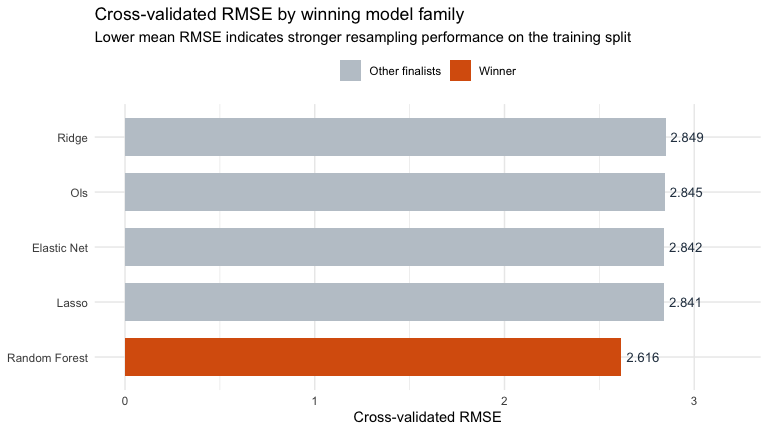

```r
# Prepare a clean plotting table so the winning family can be highlighted explicitly.
leaderboard_plot_data <- leaderboard |>
  mutate(
    model_label = tools::toTitleCase(gsub("_", " ", model)),
    highlight = if_else(row_number() == 1, "Winner", "Other finalists")
  )

# Plot the cross-validated RMSE ranking and emphasize the winner with a contrasting accent color.
ggplot(
  leaderboard_plot_data,
  aes(x = reorder(model_label, mean), y = mean, fill = highlight)
) +
  geom_col(width = 0.7) +
  geom_text(
    aes(label = sprintf("%.3f", mean)),
    hjust = -0.15,
    size = 3.5,
    color = "#2C3E50"
  ) +
  coord_flip(clip = "off") +
  scale_fill_manual(
    values = c("Winner" = "#D95F0E", "Other finalists" = "#BFC7CF")
  ) +
  expand_limits(y = max(leaderboard_plot_data$mean) * 1.12) +
  labs(
    title = "Cross-validated RMSE by winning model family",
    subtitle = "Lower mean RMSE indicates stronger resampling performance on the training split",
    x = NULL,
    y = "Cross-validated RMSE",
    fill = NULL
  ) +
  theme_minimal() +
  theme(legend.position = "top")
```

### 4.8.3) Winning model metrics

Once the cross-validated ranking has identified the winning family, the next chunk uses `last_fit()` a single time on the reserved holdout split. This follows the final-evaluation workflow recommended in *Tidy Modeling with R*: resampling selects the model, and the holdout set is then used once to summarize the predictive performance of the already-chosen winner ([workflows](https://www.tmwr.org/workflows.html), performance).

```r
# Evaluate the selected family on the reserved holdout split only once.
winning_model_last_fit <- last_fit(
  best_model_holdout_workflow,
  split = data_split,
  metrics = metric_set_regression
)

winning_model_holdout_metrics <- collect_metrics(winning_model_last_fit) |>
  mutate(model = best_model_name, variant = best_model_variant)

winning_model_holdout_predictions <- collect_predictions(winning_model_last_fit)

training_results$winning_holdout_metrics <- winning_model_holdout_metrics
training_results$winning_holdout_predictions <- winning_model_holdout_predictions

# Summarize the winning holdout metrics in a single row for quick reporting.
winning_model_summary <- training_results$winning_holdout_metrics |>
  filter(model == best_model_name) |>
  select(model, variant, .metric, .estimate) |>
  tidyr::pivot_wider(names_from = .metric, values_from = .estimate) |>
  select(model, variant, rmse, mae, rsq)

winning_model_summary
```

| model | variant | rmse | mae | rsq |
| --- | --- | --- | --- | --- |
| random_forest | minimal_preprocessing | 2.523354 | 1.975047 | 0.7449495 |

The next chunk turns the resampling ranking and the winner holdout table into a compact paragraph so the notebook explains both why the family was selected and how it validated on untouched data.

```r
# Recreate the pretty label helper here so the final selection paragraph is self-contained.
if (!exists("pretty_model_name")) {
  pretty_model_name <- function(x) {
    tools::toTitleCase(gsub("_", " ", x))
  }
}

# Gather the winner holdout metrics and the runner-up CV score to summarize the final selection in prose.
winner_holdout_metrics <- training_results$winning_holdout_metrics |>
  filter(model == best_model_name)

runner_up_entry <- leaderboard |>
  slice(2)

winner_holdout_rmse <- winner_holdout_metrics |>
  filter(.metric == "rmse") |>
  pull(.estimate)

winner_mae <- winner_holdout_metrics |>
  filter(.metric == "mae") |>
  pull(.estimate)

winner_rsquared <- winner_holdout_metrics |>
  filter(.metric == "rsq") |>
  pull(.estimate)

runner_up_name <- runner_up_entry |>
  pull(model)

winner_cv_rmse <- leaderboard |>
  slice(1) |>
  pull(mean)

runner_up_cv_rmse <- runner_up_entry |>
  pull(mean)

winner_gap <- runner_up_cv_rmse - winner_cv_rmse

# Print a compact interpretation anchored first on resampling and then on the final holdout validation.
cat(
  paste0(
    pretty_model_name(best_model_name),
    " won the final comparison because it achieved the lowest cross-validated RMSE (",
    sprintf("%.3f", winner_cv_rmse),
    "), which is the primary ranking criterion used in this notebook. ",
    "The runner-up was ",
    pretty_model_name(runner_up_name),
    " with a cross-validated RMSE of ",
    sprintf("%.3f", runner_up_cv_rmse),
    ", so the selected winner improved the main resampling metric by ",
    sprintf("%.3f", winner_gap),
    " RMSE points before the holdout set was used. Following the final-evaluation workflow recommended in *Tidy Modeling with R*, the reserved holdout split was then used once through `last_fit()`. ",
    "The winner table above shows that the deployed variant, `",
    best_model_variant,
    "`, recorded a holdout RMSE of ",
    sprintf("%.3f", winner_holdout_rmse),
    ", an MAE of ",
    sprintf("%.3f", winner_mae),
    " and an R-squared of ",
    sprintf("%.3f", winner_rsquared),
    " on unseen data. Taken together, these results indicate that the deployed workflow was selected by resampling and then validated on an untouched holdout set rather than being chosen because of that holdout result."
  )
)
```

Random Forest won the final comparison because it achieved the lowest cross-validated RMSE (2.616), which is the primary ranking criterion used in this notebook. The runner-up was Lasso with a cross-validated RMSE of 2.841, so the selected winner improved the main resampling metric by 0.225 RMSE points before the holdout set was used. Following the final-evaluation workflow recommended in *Tidy Modeling with R*, the reserved holdout split was then used once through `last_fit()`. The winner table above shows that the deployed variant, `minimal_preprocessing`, recorded a holdout RMSE of 2.523, an MAE of 1.975 and an R-squared of 0.745 on unseen data. Taken together, these results indicate that the deployed workflow was selected by resampling and then validated on an untouched holdout set rather than being chosen because of that holdout result.

The next section complements this winner summary with direct visual inspection of the deployed workflow. In this way, the notebook shows not only which family won the comparison, but also how its predictions align with the observed holdout targets under the same regression-focused evaluation logic.

### 4.8.4) Deployment handoff

The final subsection of Section 4 makes the deployment handoff explicit. Once the cross-validated winner has been validated on the holdout set, `best_model_workflow` becomes the single fitted workflow object passed into Section 6 for blind test scoring. The next chunk reports that handoff directly so the selected workflow is easy to trace from model comparison into final prediction export.

```r
# Report the workflow that will be passed into the deployment section.
deployment_handoff_summary <- tibble(
  best_model_name = best_model_name,
  variant = best_model_variant,
  handoff = "workflow selected for blind test scoring"
)

deployment_handoff_summary
```

| best_model_name | variant | handoff |
| --- | --- | --- |
| random_forest | minimal_preprocessing | workflow selected for blind test scoring |

This section is mostly **documentation and traceability**, not new modeling. Its purpose is to make the transition from **model selection** to **deployment** explicit, so the reader can clearly see which model won and which exact workflow will be used later to generate the blind-test predictions. By the time this chunk runs, the notebook has already compared all model families with cross-validation, chosen the winner, and validated that winner once on the holdout set. At that point, best_model_workflow is the fitted model object that should be carried forward into Section 6. The chunk creates a small table called deployment_handoff_summary with the winning model name, the winning variant, and a short label saying this is the workflow selected for blind-test scoring. So the real purpose of this section is not computation, but to leave a clear audit trail: “this is the exact model that now moves from evaluation into final prediction export.

# 5) Evaluation

Evaluation focuses on generalization rather than in-sample fit. Because the challenge target contains irreducible noise and the final estimates still depend on finite resamples plus a single reserved holdout split, every result in this section should be interpreted as a model-selection aid rather than as a definitive population benchmark.

Because this is a regression challenge with a continuous target, the notebook evaluates workflows with regression metrics and regression-style diagnostics rather than classification tools such as ROC curves, AUC, confusion matrices, sensitivity, or specificity. Those diagnostics are appropriate for categorical outcomes, but they would not provide a meaningful common scale for the models compared here.

## 5.1) Comparative metrics

The next chunk prints the family-level cross-validated comparison that now drives final model selection. This follows the empirical validation emphasis in *Tidy Modeling with R*, where model comparison is based on data not used to fit the corresponding resample-specific models and the test set remains reserved for a final check of the chosen winner (performance, [resampling](https://www.tmwr.org/resampling.html)).

```r
# Show the cross-validated RMSE ranking used to choose the final model family.
training_results$family_cv_leaderboard
```

| model | variant | .metric | mean | std_err | .config |
| --- | --- | --- | --- | --- | --- |
| random_forest | minimal_preprocessing | rmse | 2.615919 | 0.08046096 | pre0_mod3_post0 |
| lasso | normalized | rmse | 2.840765 | 0.08696572 | pre0_mod5_post0 |
| elastic_net | normalized | rmse | 2.842309 | 0.08694921 | pre0_mod04_post0 |
| ols | raw | rmse | 2.845045 | 0.08680131 | NA |
| ridge | normalized | rmse | 2.848861 | 0.08474115 | pre0_mod1_post0 |

This companion chunk reports the detailed cross-validated metrics collected during resampling. It acts as the more granular reference behind the family-level ranking shown above.

```r
# Show the cross-validated metrics gathered during model tuning and resampling.
training_results$resample_metrics |>
  arrange(model, variant, .metric, mean)
```

| .metric | .estimator | mean | n | std_err | .config | model | variant | penalty | mixture | mtry | min_n |
| --- | --- | --- | --- | --- | --- | --- | --- | --- | --- | --- | --- |
| mae | standard | 2.1776455 | 5 | 0.06667462 | pre0_mod04_post0 | elastic_net | normalized | 0.0000000001000 | 1.0000000 | NA | NA |
| mae | standard | 2.1776455 | 5 | 0.06667462 | pre0_mod08_post0 | elastic_net | normalized | 0.0000002154435 | 1.0000000 | NA | NA |
| mae | standard | 2.1776455 | 5 | 0.06667462 | pre0_mod12_post0 | elastic_net | normalized | 0.0004641588834 | 1.0000000 | NA | NA |
| mae | standard | 2.1777670 | 5 | 0.06660625 | pre0_mod03_post0 | elastic_net | normalized | 0.0000000001000 | 0.6666667 | NA | NA |
| mae | standard | 2.1777670 | 5 | 0.06660625 | pre0_mod07_post0 | elastic_net | normalized | 0.0000002154435 | 0.6666667 | NA | NA |
| mae | standard | 2.1777670 | 5 | 0.06660625 | pre0_mod11_post0 | elastic_net | normalized | 0.0004641588834 | 0.6666667 | NA | NA |
| mae | standard | 2.1783148 | 5 | 0.06653811 | pre0_mod02_post0 | elastic_net | normalized | 0.0000000001000 | 0.3333333 | NA | NA |
| mae | standard | 2.1783148 | 5 | 0.06653811 | pre0_mod06_post0 | elastic_net | normalized | 0.0000002154435 | 0.3333333 | NA | NA |
| mae | standard | 2.1783148 | 5 | 0.06653811 | pre0_mod10_post0 | elastic_net | normalized | 0.0004641588834 | 0.3333333 | NA | NA |
| mae | standard | 2.1923287 | 5 | 0.06374605 | pre0_mod01_post0 | elastic_net | normalized | 0.0000000001000 | 0.0000000 | NA | NA |

[output cut: 143 more lines]

## 5.2) OLS diagnostics and principles

Even if OLS is not the best predictive model, it remains the central diagnostic reference because it links directly to the OLS principles discussed in Section 2.

The following chunk fits a plain `lm()` object for classical regression diagnostics. It augments the fitted model with residual information and computes VIF values to support the discussion of OLS assumptions.

```r
# Fit a plain OLS model so classical residual diagnostics can be produced directly.
ols_model <- lm(target ~ ., data = training_data_model)
summary(ols_model)
```

```
Call:
lm(formula = target ~ ., data = training_data_model)

Residuals:
    Min      1Q  Median      3Q     Max
-11.597  -1.615   0.017   1.676   7.729

Coefficients:
               Estimate  Std. Error t value            Pr(>|t|)
(Intercept) -0.73884615  0.81305712  -0.909              0.3638
feature_0   -0.00017112  0.00037119  -0.461              0.6449
feature_1   -0.00019149  0.00058765  -0.326              0.7446
feature_2    0.01569192  0.00056688  27.681 <0.0000000000000002 ***
feature_3    0.00088570  0.00063480   1.395              0.1633
feature_4    0.00004561  0.00037045   0.123              0.9021
feature_5    0.00030698  0.00054453   0.564              0.5731
feature_6    0.00072463  0.00080901   0.896              0.3707
feature_7   -0.00007655  0.00042563  -0.180              0.8573
feature_8   -0.00033970  0.00096701  -0.351              0.7255
feature_9    0.01753278  0.00089751  19.535 <0.0000000000000002 ***
feature_10  -0.00001790  0.00043924  -0.041              0.9675
feature_11   0.82741553  0.05050200  16.384 <0.0000000000000002 ***
feature_12   0.00064866  0.00036333   1.785              0.0746 .
feature_13   0.03315884  0.00170215  19.481 <0.0000000000000002 ***
feature_14   0.00905693  0.00619653   1.462              0.1443
feature_15   0.00034619  0.00059625   0.581              0.5617
feature_16   0.00066837  0.00186057   0.359              0.7195
feature_17  -0.00485041  0.00245425  -1.976              0.0485 *
feature_18   0.01260631  0.00646310   1.951              0.0515 .
feature_19  -0.00037652  0.00037052  -1.016              0.3099
---
Signif. codes:  0 ‘***’ 0.001 ‘**’ 0.01 ‘*’ 0.05 ‘.’ 0.1 ‘ ’ 1

Residual standard error: 2.799 on 779 degrees of freedom
Multiple R-squared:  0.7052,    Adjusted R-squared:  0.6976
F-statistic: 93.16 on 20 and 779 DF,  p-value: < 0.00000000000000022
```

```r
# Add fitted values and residual diagnostics needed for later plots.
ols_diagnostics <- augment(ols_model)

# Keep a shared axis range so predicted-versus-actual comparisons use the same scale.
ols_predicted_actual_limits <- range(
  c(ols_diagnostics$target, ols_diagnostics$.fitted),
  na.rm = TRUE
)

# Compute variance inflation factors as a descriptive check on multicollinearity.
ols_vif <- tibble(
  feature = names(car::vif(ols_model)),
  vif = as.numeric(car::vif(ols_model))
) |>
  arrange(desc(vif))

head(ols_diagnostics)
```

| target | feature_0 | feature_1 | feature_2 | feature_3 | feature_4 | feature_5 | feature_6 | feature_7 | feature_8 | feature_9 | feature_10 | feature_11 | feature_12 | feature_13 | feature_14 | feature_15 | feature_16 | feature_17 | feature_18 | feature_19 | .fitted | .resid | .hat | .sigma | .cooksd | .std.resid |
| --- | --- | --- | --- | --- | --- | --- | --- | --- | --- | --- | --- | --- | --- | --- | --- | --- | --- | --- | --- | --- | --- | --- | --- | --- | --- | --- |
| 14.36492 | 432.4760 | 289.37302 | 481.3156 | 358.75557 | 802.6590 | 176.7612 | 72.6481 | 720.96918 | 36.32768 | 83.76888 | 659.39092 | 4.385848 | 516.789458 | 19.62442 | 13.1624399 | 42.351948 | 35.92039 | 20.755984 | 13.814300 | 384.49714 | 13.23658 | 1.12834633 | 0.02534901 | 2.800308 | 0.0002065292444 | 0.40836122 |
| 19.98480 | 517.5963 | 330.44834 | 585.9201 | 22.68403 | 169.8132 | 335.6016 | 284.4515 | 748.10105 | 73.70144 | 358.14722 | 11.03695 | 5.563334 | 2.960064 | 20.72188 | 17.7401838 | 1.726915 | 167.57606 | 75.492679 | 2.480979 | 303.71087 | 19.95356 | 0.03124068 | 0.03597055 | 2.800608 | 0.0000002296367 | 0.01136847 |
| 12.94435 | 189.4394 | 553.88882 | 165.8338 | 202.46593 | 176.6956 | 321.1550 | 407.2784 | 161.24567 | 282.26903 | 221.57090 | 143.91956 | 4.536947 | 581.823741 | 101.69564 | 0.6535918 | 486.859084 | 117.49155 | 6.420465 | 20.713314 | 22.65154 | 14.05786 | -1.11351373 | 0.02675402 | 2.800315 | 0.0002128967331 | -0.40328392 |
| 14.79244 | 237.3079 | 195.89488 | 416.7523 | 468.72903 | 611.6935 | 301.4117 | 241.8807 | 49.59704 | 122.39682 | 13.82832 | 677.16191 | 5.518968 | 45.014729 | 196.35045 | 47.6385148 | 411.414213 | 67.14202 | 115.630943 | 8.927957 | 388.24043 | 17.74918 | -2.95674530 | 0.02864710 | 2.798542 | 0.0016135722382 | -1.07189448 |
| 11.80263 | 602.8453 | 16.10321 | 221.7600 | 345.76557 | 558.5884 | 276.7042 | 408.0696 | 19.39081 | 138.76976 | 146.66219 | 311.74757 | 2.136214 | 133.590430 | 197.63458 | 26.2780274 | 111.127557 | 172.18114 | 85.869642 | 30.537857 | 625.93184 | 14.39617 | -2.59353816 | 0.02237184 | 2.799028 | 0.0009571359204 | -0.93720032 |
| 21.27125 | 888.4915 | 403.68986 | 417.7298 | 344.50267 | 361.1039 | 292.0586 | 259.3848 | 302.26434 | 143.10353 | 224.03767 | 601.58432 | 4.472591 | 768.429387 | 202.34040 | 49.4729328 | 560.170463 | 67.84709 | 23.812373 | 33.041312 | 270.38076 | 21.82657 | -0.55532054 | 0.02071036 | 2.800536 | 0.0000404843168 | -0.20050019 |

```r
ols_vif
```

| feature | vif |
| --- | --- |
| feature_4 | 1.040143 |
| feature_5 | 1.036863 |
| feature_13 | 1.033962 |
| feature_8 | 1.032821 |
| feature_0 | 1.030594 |
| feature_12 | 1.027952 |
| feature_10 | 1.027774 |
| feature_16 | 1.027738 |
| feature_11 | 1.026449 |
| feature_1 | 1.026248 |

[output cut: 10 more lines]

### 5.2.1) Predicted vs actual

The next chunk compares the observed target values against the fitted OLS values. Points closer to the 45-degree diagonal indicate tighter in-sample agreement, but this figure should still be read as a descriptive OLS diagnostic rather than as the notebook’s final generalization criterion.

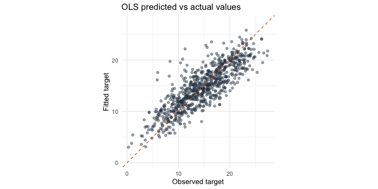

```r
# Compare observed and fitted OLS values on a shared scale to assess in-sample alignment.
ggplot(ols_diagnostics, aes(x = target, y = .fitted)) +
  geom_point(alpha = 0.45, color = "#2C3E50") +
  geom_abline(slope = 1, intercept = 0, linetype = "dashed", color = "#D95F0E") +
  coord_equal(
    xlim = ols_predicted_actual_limits,
    ylim = ols_predicted_actual_limits
  ) +
  labs(
    title = "OLS predicted vs actual values",
    x = "Observed target",
    y = "Fitted target"
  ) +
  theme_minimal()
```

### 5.2.2) Residuals vs fitted

The next chunk draws the residuals-versus-fitted plot. This diagnostic is used to look for patterns that may suggest non-linearity or changing residual variance.

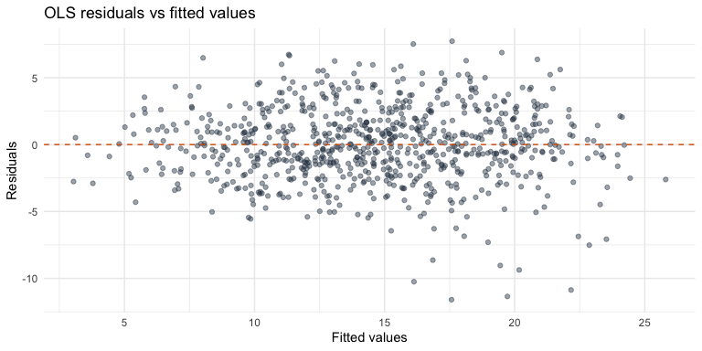

```r
# Plot residuals against fitted values to check for structure that OLS should not leave behind.
ggplot(ols_diagnostics, aes(x = .fitted, y = .resid)) +
  geom_point(alpha = 0.45, color = "#2C3E50") +
  geom_hline(yintercept = 0, linetype = "dashed", color = "#D95F0E") +
  labs(
    title = "OLS residuals vs fitted values",
    x = "Fitted values",
    y = "Residuals"
  ) +
  theme_minimal()
```

### 5.2.3) Normal Q-Q

The following chunk produces a normal Q-Q plot for standardized residuals. This plot helps assess whether the residual distribution departs strongly from normality.

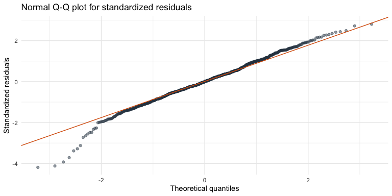

```r
# Compare standardized residuals against theoretical normal quantiles.
ggplot(ols_diagnostics, aes(sample = .std.resid)) +
  stat_qq(color = "#2C3E50", alpha = 0.5) +
  stat_qq_line(color = "#D95F0E") +
  labs(
    title = "Normal Q-Q plot for standardized residuals",
    x = "Theoretical quantiles",
    y = "Standardized residuals"
  ) +
  theme_minimal()
```

### 5.2.4) Scale-location style diagnostic

The next chunk creates a scale-location style plot. Its purpose is to inspect whether residual spread changes systematically across the range of fitted values.

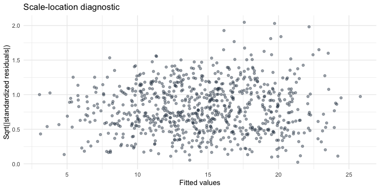

```r
# Plot the square root of the absolute standardized residuals against fitted values.
ggplot(
  ols_diagnostics,
  aes(x = .fitted, y = sqrt(abs(.std.resid)))
) +
  geom_point(alpha = 0.45, color = "#2C3E50") +
  labs(
    title = "Scale-location diagnostic",
    x = "Fitted values",
    y = "Sqrt(|standardized residuals|)"
  ) +
  theme_minimal()
```

## 5.3) Final winning model diagnostics

The final subsection shifts attention from the OLS reference model to the workflow actually selected for deployment. The next chunk gathers the winning model’s holdout predictions from the single `last_fit()` call, computes residual-based summaries on unseen data, and extracts variable importance when the deployed workflow is a random forest.

```r
# Reuse the winner label in the plots below so the deployed family is easy to identify.
if (!exists("pretty_model_name")) {
  pretty_model_name <- function(x) {
    tools::toTitleCase(gsub("_", " ", x))
  }
}

winning_model_label <- pretty_model_name(best_model_name)

# Reuse the single holdout-evaluation predictions gathered for the winning workflow.
winning_model_holdout_predictions <- training_results$winning_holdout_predictions

winning_model_diagnostics <- winning_model_holdout_predictions |>
  mutate(
    truth = .data[["target"]],
    residual = truth - .pred,
    abs_error = abs(residual)
  )

winning_model_prediction_limits <- range(
  c(winning_model_diagnostics$truth, winning_model_diagnostics$.pred),
  na.rm = TRUE
)

winning_model_error_summary <- tibble(
  model = best_model_name,
  variant = winning_model_summary |> pull(variant),
  mean_absolute_error = mean(winning_model_diagnostics$abs_error),
  median_absolute_error = median(winning_model_diagnostics$abs_error),
  max_absolute_error = max(winning_model_diagnostics$abs_error)
)

# Extract impurity-based importance only when the deployed workflow is a random forest.
if (best_model_name == "random_forest") {
  rf_importance_vector <- workflows::extract_fit_parsnip(random_forest_fitted_workflow)$fit$variable.importance

  winning_model_importance <- tibble(
    feature = names(rf_importance_vector),
    importance = as.numeric(rf_importance_vector)
  ) |>
    arrange(desc(importance)) |>
    slice_head(n = 10)
} else {
  winning_model_importance <- tibble(
    feature = character(),
    importance = numeric()
  )
}

head(winning_model_diagnostics)
```

| .pred | id | target | .row | .config | truth | residual | abs_error |
| --- | --- | --- | --- | --- | --- | --- | --- |
| 14.59368 | train/test split | 14.36492 | 1 | pre0_mod0_post0 | 14.36492 | -0.2287588 | 0.2287588 |
| 16.52281 | train/test split | 14.79244 | 4 | pre0_mod0_post0 | 14.79244 | -1.7303745 | 1.7303745 |
| 10.57837 | train/test split | 11.80263 | 5 | pre0_mod0_post0 | 11.80263 | 1.2242597 | 1.2242597 |
| 14.21200 | train/test split | 13.51394 | 10 | pre0_mod0_post0 | 13.51394 | -0.6980658 | 0.6980658 |
| 13.19350 | train/test split | 11.33250 | 14 | pre0_mod0_post0 | 11.33250 | -1.8610062 | 1.8610062 |
| 17.67516 | train/test split | 21.88555 | 43 | pre0_mod0_post0 | 21.88555 | 4.2103918 | 4.2103918 |

```r
winning_model_error_summary
```

| model | variant | mean_absolute_error | median_absolute_error | max_absolute_error |
| --- | --- | --- | --- | --- |
| random_forest | minimal_preprocessing | 1.975047 | 1.670238 | 8.361734 |

### 5.3.1) Predicted vs actual for the winning model

The next chart extends the ranking table with a direct out-of-sample view of the deployed workflow. Points closer to the 45-degree reference line indicate tighter agreement between the holdout observations and the predictions produced by the final selected model.

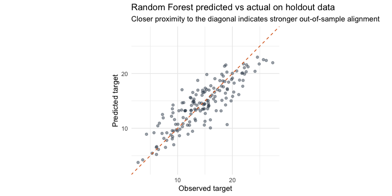

```r
# Compare observed and predicted holdout values for the deployed workflow on a shared scale.
ggplot(winning_model_diagnostics, aes(x = truth, y = .pred)) +
  geom_point(alpha = 0.45, color = "#2C3E50") +
  geom_abline(slope = 1, intercept = 0, linetype = "dashed", color = "#D95F0E") +
  coord_equal(
    xlim = winning_model_prediction_limits,
    ylim = winning_model_prediction_limits
  ) +
  labs(
    title = paste(winning_model_label, "predicted vs actual on holdout data"),
    subtitle = "Closer proximity to the diagonal indicates stronger out-of-sample alignment",
    x = "Observed target",
    y = "Predicted target"
  ) +
  theme_minimal()
```

### 5.3.2) Error profile of the winning model

The next summary and figure complement the winner table with a more concrete view of the model’s errors on the reserved holdout set. Since `RMSE` remains the decisive metric, this subsection is interpretative: it helps show whether the deployed workflow’s errors stay concentrated within a relatively narrow range or are dominated by a small number of larger misses.

```r
# Report a compact summary of the absolute errors made by the deployed workflow.
winning_model_error_summary
```

| model | variant | mean_absolute_error | median_absolute_error | max_absolute_error |
| --- | --- | --- | --- | --- |
| random_forest | minimal_preprocessing | 1.975047 | 1.670238 | 8.361734 |

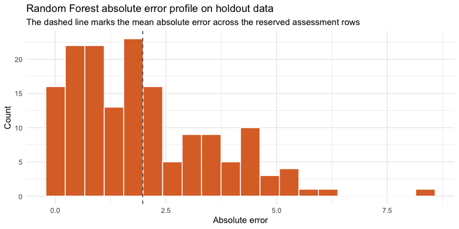

```r
# Plot the distribution of absolute holdout errors and mark the mean absolute error.
ggplot(winning_model_diagnostics, aes(x = abs_error)) +
  geom_histogram(bins = 20, fill = "#D95F0E", color = "white", alpha = 0.9) +
  geom_vline(
    xintercept = winning_model_error_summary$mean_absolute_error,
    linetype = "dashed",
    color = "#2C3E50"
  ) +
  labs(
    title = paste(winning_model_label, "absolute error profile on holdout data"),
    subtitle = "The dashed line marks the mean absolute error across the reserved assessment rows",
    x = "Absolute error",
    y = "Count"
  ) +
  theme_minimal()
```

### 5.3.3) Variable importance for the winning random forest

If the deployed workflow is a random forest, the next figure visualizes the top impurity-based importance scores extracted from the fitted forest. This chart is interpretative rather than decisive: it helps identify which predictors contributed most to the winning tree ensemble, but it is not used as the selection criterion in the notebook.

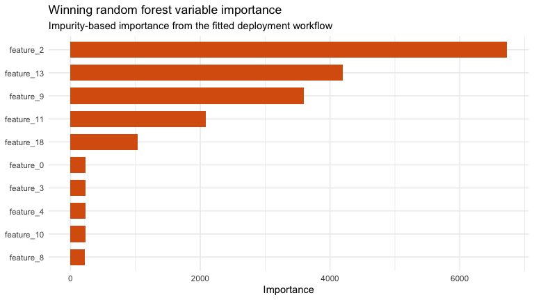

```r
# Plot the top variable-importance scores only when the deployed workflow is a random forest.
if (best_model_name == "random_forest") {
  ggplot(
    winning_model_importance,
    aes(x = reorder(feature, importance), y = importance)
  ) +
    geom_col(fill = "#D95F0E", width = 0.7) +
    coord_flip() +
    labs(
      title = "Winning random forest variable importance",
      subtitle = "Impurity-based importance from the fitted deployment workflow",
      x = NULL,
      y = "Importance"
    ) +
    theme_minimal()
} else {
  cat("Variable importance is omitted here because the deployed workflow is not a random forest.")
}
```

# 6) Deployment

The last phase operationalizes the final deliverable of the challenge: a CSV with blind test predictions in a single column named `target_pred`.

## 6.1) Final blind test scoring

The final analytical chunk generates the submission-ready prediction file. It creates the output directory if needed, scores the blind test dataset with the selected workflow, and exports the results in the one-column format required by the challenge.

```r
# Create the output directory if it does not already exist.
dir.create("output", recursive = TRUE, showWarnings = FALSE)

# Score the blind test rows and rename the prediction column to the expected submission label.
blind_test_predictions <- predict(best_model_workflow, new_data = blind_test_data_model) |>
  rename(target_pred = .pred)

# Export the predictions in the exact single-column CSV format expected for submission.
write_csv(blind_test_predictions, "output/blind_test_predictions.csv")

head(blind_test_predictions)
```

| target_pred |
| --- |
| 13.793016 |
| 13.914662 |
| 14.606431 |
| 12.274028 |
| 17.443014 |
| 9.666223 |

The exported file is now saved as `output/blind_test_predictions.csv`, and it is ready for submission after confirming that the required one-column format has been preserved.

## 6.2) Future development

[figure not shown]

Implementing a **CI/CD pipeline with R, Docker, and Google Cloud Run** would be a strong next step to move this project from a local analytical workflow into a more production-ready setup. Right now, the project is reproducible and well documented, but execution still depends on running the code manually. A CI/CD pipeline would make the process more robust by automatically validating, packaging, and deploying changes whenever the codebase is updated.

The proposed flow would start in **RStudio**, where the model logic or an application layer built with **Shiny** or **Plumber** is developed. The full project, including the source code and a Dockerfile, would then be versioned in **GitHub**. From there, **Cloud Build** could automatically build the container image after each push or merge, run basic checks, and publish the versioned image to **Artifact Registry**. This would ensure that the same environment is preserved across development, testing, and deployment, which is especially important in data science and machine learning projects.

Finally, **Cloud Run** would serve as the deployment layer, allowing the application or model service to run in a serverless and scalable way without managing infrastructure directly. This would make it possible to expose the model as an API for prediction, a lightweight web application, or another inference service. Overall, this recommendation would improve reproducibility, traceability, scalability, and maintainability, turning the project from a strong analytical deliverable into a solution that is also ready for operational use.

This is an example of a Shiny app that I deploy in a CI/CD pipe line with R, Docker and Google Cloud: https://senda-hotel-san-bartolome-encuesta-465823837236.northamerica-south1.run.app